# Credit Screening Dataset

This dataset has been downloaded from UC Irvine Machine Learning Repository.  
https://archive.ics.uci.edu/ml/datasets/Credit+Approval

This dataset is regarding credit card applications.  
The target variable/label is whether the application has been granted credit or not.  
All attribute names and values have been changed to meaningless symbols to protect confidentiality of the data.

**The objective is here to build a model to give binary output based on the input attributes.**

> **Summary of Key information**

```
Number of Instances/training examples          : 690
Number of Instances with missing attributes    :  37
Number of qualified Instances/training examples : 653

Number of Input Attributes                     : 15
Number of categorical attributes               :  9
Number of numerical attributes                 :  6

Target Attribute Type                          : Binary Class
Target Class distribution                      : 54%:45%
Problem Identification                         : Binary Classification with balanced data set
```

```python
import os
print(os.environ['PATH'])
```

```
/usr/local/lib/ruby/gems/3.1.0/bin:/usr/local/opt/ruby/bin:/usr/local/lib/ruby/gems/3.1.0/bin:/usr/local/opt/ruby/bin:/Users/bhaskarroy/opt/anaconda3/bin:/Users/bhaskarroy/opt/anaconda3/condabin:/usr/local/bin:/usr/bin:/bin:/usr/sbin:/sbin:/Library/TeX/texbin:/usr/local/share/dotnet:~/.dotnet/tools:…
```

```python
from notebook.services.config import ConfigManager
cm = ConfigManager().update('notebook', {'limit_output': 20})
```

# Loading necessary libraries

```python
import numpy as np
import pandas as pd
import time
import seaborn as sns
import matplotlib.pyplot as plt

from eda import eda_overview, axes_utils

import category_encoders as ce
from sklearn.preprocessing import LabelEncoder
from sklearn.preprocessing import OrdinalEncoder

from sklearn.model_selection import train_test_split, learning_curve, KFold, cross_val_score
from sklearn.linear_model import LogisticRegression
from sklearn.tree import DecisionTreeClassifier
from sklearn.neighbors import KNeighborsClassifier
from sklearn.naive_bayes import GaussianNB
from sklearn.ensemble import RandomForestClassifier, GradientBoostingClassifier
from sklearn.svm import LinearSVC
from sklearn.discriminant_analysis import LinearDiscriminantAnalysis

from sklearn.metrics import recall_score, precision_score, accuracy_score,confusion_matrix, ConfusionMatrixDisplay, classification_report, f1_score
```

```python
pd.set_option('display.max_rows', 20)
pd.set_option('precision', 4)
```

# Importing the dataset

```python
path = "/Users/bhaskarroy/BHASKAR FILES/BHASKAR CAREER/Data Science/Practise/"  \
       "Python/UCI Machine Learning Repository/Credit Screening/"
```

```python
# Index
# credit.lisp
# credit.names
# crx.data
# crx.names


path1 = path + "crx.data"
path_name = path + "credit.names"
path_crxname = path + "crx.names"
```

```python
datContent = [i.strip().split() for i in open(path1).readlines()]
```

```python
len(datContent)
```

```
690
```

```python
print(dir(type(datContent[0][0])))
```

```
['__add__', '__class__', '__contains__', '__delattr__', '__dir__', '__doc__', '__eq__', '__format__', '__ge__', '__getattribute__', '__getitem__', '__getnewargs__', '__gt__', '__hash__', '__init__', '__init_subclass__', '__iter__', '__le__', '__len__', '__lt__', '__mod__', '__mul__', '__ne__', '__ne…
```

```python
# Inspecting the contents
print(datContent[0][0].split(sep = ","))
```

```
['b', '30.83', '0', 'u', 'g', 'w', 'v', '1.25', 't', 't', '01', 'f', 'g', '00202', '0', '+']
```

```python
len(datContent[0])
```

```
1
```

# Dataset Information

```python
# Opening the file credit.names for the description of data set
with open(path_name) as f:
    print(f.read())
```

```
1. Title: Japanese Credit Screening (examples & domain theory)

2. Source information:
   -- Creators: Chiharu Sano
   -- Donor: Chiharu Sano
             csano@bonnie.ICS.UCI.EDU
   -- Date: 3/19/92

3. Past usage:
   -- None Published

4. Relevant information:
   --  Examples represent positive and negative instances of people who were and were not
       granted credit.
   --  The theory was generated by talking to the individuals at a Japanese company that grants
       credit.

5. Number of instances: 125
```

# Attributes Information

```python
# Opening the file crx.names for the description of data set
with open(path_crxname) as f:
    print(f.read())
```

```
1. Title: Credit Approval

2. Sources:
    (confidential)
    Submitted by quinlan@cs.su.oz.au

3.  Past Usage:

    See Quinlan,
    * "Simplifying decision trees", Int J Man-Machine Studies 27,
      Dec 1987, pp. 221-234.
    * "C4.5: Programs for Machine Learning", Morgan Kaufmann, Oct 1992

4.  Relevant Information:

    This file concerns credit card applications.  All attribute names
    and values have been changed to meaningless symbols to protect
    confidentiality of the data.

    This dataset is interesting because there is a good mix of
    attributes -- continuous, nominal with small numbers of
    values, and nominal with larger numbers of values.  There
    are also a few missing values.

5.  Number of Instances: 690

6.  Number of Attributes: 15 + class attribute

7.  Attribute Information:

    A1:	b, a.
    A2:	continuous.
    A3:	continuous.
    A4:	u, y, l, t.
    A5:	g, p, gg.
    A6:	c, d, cc, i, j, k, m, r, q, w, x, e, aa, ff.
    A7:	v, h, bb, j, n, z, dd, ff, o.
    A8:	continuous.
    A9:	t, f.
    A10:	t, f.
```

[output cut: 8 more lines]

```
    37 cases (5%) have one or more missing values.  The missing
    values from particular attributes are:

    A1:  12
    A2:  12
    A4:   6
    A5:   6
    A6:   9
    A7:   9
    A14: 13

9.  Class Distribution

    +: 307 (44.5%)
    -: 383 (55.5%)
```

```python
with open(path+"Index") as f:
    print(f.read())
```

```
Index of credit-screening

02 Dec 1996      182 Index
19 Sep 1992    32218 crx.data
19 Sep 1992     1486 crx.names
16 Jul 1992    12314 credit.lisp
16 Jul 1992      522 credit.names
```

```python
#with open(path+"credit.lisp") as f:
#    print(f.read())
```

# Data preprocessing

Following actions were undertaken:

- Converting to Dataframe Format
- As attribute names are anonymised, create standard feature name starting with 'A' and suffixed with feature number
- Handling Missing values : 37 rows had missing values and are not being considered for model building
- Converting Class symbols of Target variable to binary values
- Processing Continous Attributes : Based on inspection, continuous attributes have been converted to float type.

## Converting to Dataframe Format

```python
# Inspecting the data
# We find that all the elements in a row is fused as one element.
# We need to use comma for splitting
datContent[0:5]
```

```
[['b,30.83,0,u,g,w,v,1.25,t,t,01,f,g,00202,0,+'],
 ['a,58.67,4.46,u,g,q,h,3.04,t,t,06,f,g,00043,560,+'],
 ['a,24.50,0.5,u,g,q,h,1.5,t,f,0,f,g,00280,824,+'],
 ['b,27.83,1.54,u,g,w,v,3.75,t,t,05,t,g,00100,3,+'],
 ['b,20.17,5.625,u,g,w,v,1.71,t,f,0,f,s,00120,0,+']]
```

```python
# Splitting using comma to get individual elements
print(datContent[0][0].split(sep = ","))
```

```
['b', '30.83', '0', 'u', 'g', 'w', 'v', '1.25', 't', 't', '01', 'f', 'g', '00202', '0', '+']
```

```python
# The Number of attributes/features is 16
attrCount = len(datContent[0][0].split(sep = ","))
attrCount
```

```
16
```

```python
# As all features names have been changed/anonymised,
# we will create standard feature name starting with 'A' and suffixed with feature number
colNames = ["A"+str(i+1) for i in range(attrCount)]
print(colNames)
```

```
['A1', 'A2', 'A3', 'A4', 'A5', 'A6', 'A7', 'A8', 'A9', 'A10', 'A11', 'A12', 'A13', 'A14', 'A15', 'A16']
```

```python
# Extracting values/data that will be passed as data to create the Dataframe
rawData = []

for i in datContent:
    for j in i:
        rawData.append(j.split(sep = ","))
```

```python
# Creating the Dataframe
df = pd.DataFrame(rawData, columns = colNames)

# Inspecting the Dataframe
df.head()
```

|  | A1 | A2 | A3 | A4 | A5 | A6 | A7 | A8 | A9 | A10 | A11 | A12 | A13 | A14 | A15 | A16 |
| --- | --- | --- | --- | --- | --- | --- | --- | --- | --- | --- | --- | --- | --- | --- | --- | --- |
| 0 | b | 30.83 | 0 | u | g | w | v | 1.25 | t | t | 01 | f | g | 00202 | 0 | + |
| 1 | a | 58.67 | 4.46 | u | g | q | h | 3.04 | t | t | 06 | f | g | 00043 | 560 | + |
| 2 | a | 24.50 | 0.5 | u | g | q | h | 1.5 | t | f | 0 | f | g | 00280 | 824 | + |
| 3 | b | 27.83 | 1.54 | u | g | w | v | 3.75 | t | t | 05 | t | g | 00100 | 3 | + |
| 4 | b | 20.17 | 5.625 | u | g | w | v | 1.71 | t | f | 0 | f | s | 00120 | 0 | + |

```python
# Inspecting the dataframe
# We find that features 'A2','A16' have symbols that would require further preprocessing
df.describe()
```

|  | A1 | A2 | A3 | A4 | A5 | A6 | A7 | A8 | A9 | A10 | A11 | A12 | A13 | A14 | A15 | A16 |
| --- | --- | --- | --- | --- | --- | --- | --- | --- | --- | --- | --- | --- | --- | --- | --- | --- |
| count | 690 | 690 | 690 | 690 | 690 | 690 | 690 | 690 | 690 | 690 | 690 | 690 | 690 | 690 | 690 | 690 |
| unique | 3 | 350 | 215 | 4 | 4 | 15 | 10 | 132 | 2 | 2 | 23 | 2 | 3 | 171 | 240 | 2 |
| top | b | ? | 1.5 | u | g | c | v | 0 | t | f | 0 | f | g | 00000 | 0 | - |
| freq | 468 | 12 | 21 | 519 | 519 | 137 | 399 | 70 | 361 | 395 | 395 | 374 | 625 | 132 | 295 | 383 |

```python
# Checking the datatypes to decide the datatype conversions required feature wise
df.info()
```

```
<class 'pandas.core.frame.DataFrame'>
RangeIndex: 690 entries, 0 to 689
Data columns (total 16 columns):
 #   Column  Non-Null Count  Dtype
---  ------  --------------  -----
 0   A1      690 non-null    object
 1   A2      690 non-null    object
 2   A3      690 non-null    object
 3   A4      690 non-null    object
 4   A5      690 non-null    object
 5   A6      690 non-null    object
 6   A7      690 non-null    object
 7   A8      690 non-null    object
 8   A9      690 non-null    object
 9   A10     690 non-null    object
 10  A11     690 non-null    object
 11  A12     690 non-null    object
 12  A13     690 non-null    object
 13  A14     690 non-null    object
 14  A15     690 non-null    object
 15  A16     690 non-null    object
dtypes: object(16)
memory usage: 86.4+ KB
```

## Handling Missing values

```python
#df['A2'].astype("float")
df1 = df[(df == "?").any(axis = 1)]
```

```python
df1
```

|  | A1 | A2 | A3 | A4 | A5 | A6 | A7 | A8 | A9 | A10 | A11 | A12 | A13 | A14 | A15 | A16 |
| --- | --- | --- | --- | --- | --- | --- | --- | --- | --- | --- | --- | --- | --- | --- | --- | --- |
| 71 | b | 34.83 | 4 | u | g | d | bb | 12.5 | t | f | 0 | t | g | ? | 0 | - |
| 83 | a | ? | 3.5 | u | g | d | v | 3 | t | f | 0 | t | g | 00300 | 0 | - |
| 86 | b | ? | 0.375 | u | g | d | v | 0.875 | t | f | 0 | t | s | 00928 | 0 | - |
| 92 | b | ? | 5 | y | p | aa | v | 8.5 | t | f | 0 | f | g | 00000 | 0 | - |
| 97 | b | ? | 0.5 | u | g | c | bb | 0.835 | t | f | 0 | t | s | 00320 | 0 | - |
| ... | ... | ... | ... | ... | ... | ... | ... | ... | ... | ... | ... | ... | ... | ... | ... | ... |
| 608 | b | ? | 0.04 | y | p | d | v | 4.25 | f | f | 0 | t | g | 00460 | 0 | - |
| 622 | a | 25.58 | 0 | ? | ? | ? | ? | 0 | f | f | 0 | f | p | ? | 0 | + |
| 626 | b | 22.00 | 7.835 | y | p | i | bb | 0.165 | f | f | 0 | t | g | ? | 0 | - |
| 641 | ? | 33.17 | 2.25 | y | p | cc | v | 3.5 | f | f | 0 | t | g | 00200 | 141 | - |
| 673 | ? | 29.50 | 2 | y | p | e | h | 2 | f | f | 0 | f | g | 00256 | 17 | - |

37 rows × 16 columns

```python
# Selecting a subset without any missing values
df2 = df[(df != "?").all(axis = 1)]
df2.shape
```

```
(653, 16)
```

```python
df2.head()
```

|  | A1 | A2 | A3 | A4 | A5 | A6 | A7 | A8 | A9 | A10 | A11 | A12 | A13 | A14 | A15 | A16 |
| --- | --- | --- | --- | --- | --- | --- | --- | --- | --- | --- | --- | --- | --- | --- | --- | --- |
| 0 | b | 30.83 | 0 | u | g | w | v | 1.25 | t | t | 01 | f | g | 00202 | 0 | + |
| 1 | a | 58.67 | 4.46 | u | g | q | h | 3.04 | t | t | 06 | f | g | 00043 | 560 | + |
| 2 | a | 24.50 | 0.5 | u | g | q | h | 1.5 | t | f | 0 | f | g | 00280 | 824 | + |
| 3 | b | 27.83 | 1.54 | u | g | w | v | 3.75 | t | t | 05 | t | g | 00100 | 3 | + |
| 4 | b | 20.17 | 5.625 | u | g | w | v | 1.71 | t | f | 0 | f | s | 00120 | 0 | + |

## Converting Class symbols of Target variable to binary values

```python
# Below code may return Setting with Copy warning
# Use df._is_view to check if a dataframe is a view or copy
# df2.loc[:, 'A16'] = df2['A16'].map({"-": 0, "+":1}).values

# Use df.assign instead.
# https://stackoverflow.com/questions/36846060/how-to-replace-an-entire-column-on-pandas-dataframe
df2 = df2.assign(A16 = df2['A16'].map({"-": 0, "+":1}))
```

```python
df2
```

|  | A1 | A2 | A3 | A4 | A5 | A6 | A7 | A8 | A9 | A10 | A11 | A12 | A13 | A14 | A15 | A16 |
| --- | --- | --- | --- | --- | --- | --- | --- | --- | --- | --- | --- | --- | --- | --- | --- | --- |
| 0 | b | 30.83 | 0 | u | g | w | v | 1.25 | t | t | 01 | f | g | 00202 | 0 | 1 |
| 1 | a | 58.67 | 4.46 | u | g | q | h | 3.04 | t | t | 06 | f | g | 00043 | 560 | 1 |
| 2 | a | 24.50 | 0.5 | u | g | q | h | 1.5 | t | f | 0 | f | g | 00280 | 824 | 1 |
| 3 | b | 27.83 | 1.54 | u | g | w | v | 3.75 | t | t | 05 | t | g | 00100 | 3 | 1 |
| 4 | b | 20.17 | 5.625 | u | g | w | v | 1.71 | t | f | 0 | f | s | 00120 | 0 | 1 |
| ... | ... | ... | ... | ... | ... | ... | ... | ... | ... | ... | ... | ... | ... | ... | ... | ... |
| 685 | b | 21.08 | 10.085 | y | p | e | h | 1.25 | f | f | 0 | f | g | 00260 | 0 | 0 |
| 686 | a | 22.67 | 0.75 | u | g | c | v | 2 | f | t | 02 | t | g | 00200 | 394 | 0 |
| 687 | a | 25.25 | 13.5 | y | p | ff | ff | 2 | f | t | 01 | t | g | 00200 | 1 | 0 |
| 688 | b | 17.92 | 0.205 | u | g | aa | v | 0.04 | f | f | 0 | f | g | 00280 | 750 | 0 |
| 689 | b | 35.00 | 3.375 | u | g | c | h | 8.29 | f | f | 0 | t | g | 00000 | 0 | 0 |

653 rows × 16 columns

```python
df2
```

|  | A1 | A2 | A3 | A4 | A5 | A6 | A7 | A8 | A9 | A10 | A11 | A12 | A13 | A14 | A15 | A16 |
| --- | --- | --- | --- | --- | --- | --- | --- | --- | --- | --- | --- | --- | --- | --- | --- | --- |
| 0 | b | 30.83 | 0 | u | g | w | v | 1.25 | t | t | 01 | f | g | 00202 | 0 | 1 |
| 1 | a | 58.67 | 4.46 | u | g | q | h | 3.04 | t | t | 06 | f | g | 00043 | 560 | 1 |
| 2 | a | 24.50 | 0.5 | u | g | q | h | 1.5 | t | f | 0 | f | g | 00280 | 824 | 1 |
| 3 | b | 27.83 | 1.54 | u | g | w | v | 3.75 | t | t | 05 | t | g | 00100 | 3 | 1 |
| 4 | b | 20.17 | 5.625 | u | g | w | v | 1.71 | t | f | 0 | f | s | 00120 | 0 | 1 |
| ... | ... | ... | ... | ... | ... | ... | ... | ... | ... | ... | ... | ... | ... | ... | ... | ... |
| 685 | b | 21.08 | 10.085 | y | p | e | h | 1.25 | f | f | 0 | f | g | 00260 | 0 | 0 |
| 686 | a | 22.67 | 0.75 | u | g | c | v | 2 | f | t | 02 | t | g | 00200 | 394 | 0 |
| 687 | a | 25.25 | 13.5 | y | p | ff | ff | 2 | f | t | 01 | t | g | 00200 | 1 | 0 |
| 688 | b | 17.92 | 0.205 | u | g | aa | v | 0.04 | f | f | 0 | f | g | 00280 | 750 | 0 |
| 689 | b | 35.00 | 3.375 | u | g | c | h | 8.29 | f | f | 0 | t | g | 00000 | 0 | 0 |

653 rows × 16 columns

```python
from eda import datasets
datasets.credit_screening()
```

|  | A1 | A2 | A3 | A4 | A5 | A6 | A7 | A8 | A9 | A10 | A11 | A12 | A13 | A14 | A15 | A16 |
| --- | --- | --- | --- | --- | --- | --- | --- | --- | --- | --- | --- | --- | --- | --- | --- | --- |
| 0 | b | 30.83 | 0.000 | u | g | w | v | 1.25 | t | t | 1.0 | f | g | 202.0 | 0.0 | 1 |
| 1 | a | 58.67 | 4.460 | u | g | q | h | 3.04 | t | t | 6.0 | f | g | 43.0 | 560.0 | 1 |
| 2 | a | 24.50 | 0.500 | u | g | q | h | 1.50 | t | f | 0.0 | f | g | 280.0 | 824.0 | 1 |
| 3 | b | 27.83 | 1.540 | u | g | w | v | 3.75 | t | t | 5.0 | t | g | 100.0 | 3.0 | 1 |
| 4 | b | 20.17 | 5.625 | u | g | w | v | 1.71 | t | f | 0.0 | f | s | 120.0 | 0.0 | 1 |
| ... | ... | ... | ... | ... | ... | ... | ... | ... | ... | ... | ... | ... | ... | ... | ... | ... |
| 685 | b | 21.08 | 10.085 | y | p | e | h | 1.25 | f | f | 0.0 | f | g | 260.0 | 0.0 | 0 |
| 686 | a | 22.67 | 0.750 | u | g | c | v | 2.00 | f | t | 2.0 | t | g | 200.0 | 394.0 | 0 |
| 687 | a | 25.25 | 13.500 | y | p | ff | ff | 2.00 | f | t | 1.0 | t | g | 200.0 | 1.0 | 0 |
| 688 | b | 17.92 | 0.205 | u | g | aa | v | 0.04 | f | f | 0.0 | f | g | 280.0 | 750.0 | 0 |
| 689 | b | 35.00 | 3.375 | u | g | c | h | 8.29 | f | f | 0.0 | t | g | 0.0 | 0.0 | 0 |

653 rows × 16 columns

## Processing Continous Attributes

```python
# Continous Variables are A2, A3, A11, A14, A15
contAttr = ['A2', 'A3','A8', 'A11', 'A14', 'A15']
```

```python
for i in contAttr:
    df2.loc[:,i] = df2[i].astype("float")
```

```python
df2
```

|  | A1 | A2 | A3 | A4 | A5 | A6 | A7 | A8 | A9 | A10 | A11 | A12 | A13 | A14 | A15 | A16 |
| --- | --- | --- | --- | --- | --- | --- | --- | --- | --- | --- | --- | --- | --- | --- | --- | --- |
| 0 | b | 30.83 | 0.000 | u | g | w | v | 1.25 | t | t | 1.0 | f | g | 202.0 | 0.0 | 1 |
| 1 | a | 58.67 | 4.460 | u | g | q | h | 3.04 | t | t | 6.0 | f | g | 43.0 | 560.0 | 1 |
| 2 | a | 24.50 | 0.500 | u | g | q | h | 1.50 | t | f | 0.0 | f | g | 280.0 | 824.0 | 1 |
| 3 | b | 27.83 | 1.540 | u | g | w | v | 3.75 | t | t | 5.0 | t | g | 100.0 | 3.0 | 1 |
| 4 | b | 20.17 | 5.625 | u | g | w | v | 1.71 | t | f | 0.0 | f | s | 120.0 | 0.0 | 1 |
| ... | ... | ... | ... | ... | ... | ... | ... | ... | ... | ... | ... | ... | ... | ... | ... | ... |
| 685 | b | 21.08 | 10.085 | y | p | e | h | 1.25 | f | f | 0.0 | f | g | 260.0 | 0.0 | 0 |
| 686 | a | 22.67 | 0.750 | u | g | c | v | 2.00 | f | t | 2.0 | t | g | 200.0 | 394.0 | 0 |
| 687 | a | 25.25 | 13.500 | y | p | ff | ff | 2.00 | f | t | 1.0 | t | g | 200.0 | 1.0 | 0 |
| 688 | b | 17.92 | 0.205 | u | g | aa | v | 0.04 | f | f | 0.0 | f | g | 280.0 | 750.0 | 0 |
| 689 | b | 35.00 | 3.375 | u | g | c | h | 8.29 | f | f | 0.0 | t | g | 0.0 | 0.0 | 0 |

653 rows × 16 columns

# Univariate Analysis - Continous Variables

Findings from the distribution of numeric variables at overall level and considering the application status are as below:

- The dispersion/standard deviation of numeric variables for the applications granted credit extends over a wide range.
- The shape of distribution is similar in both groups for the variables 'A2', 'A3' and 'A14'.
- In particular, Numeric variables **'A11' and 'A15'** is concentrated to a **very narrow range** for the applications not granted credit.

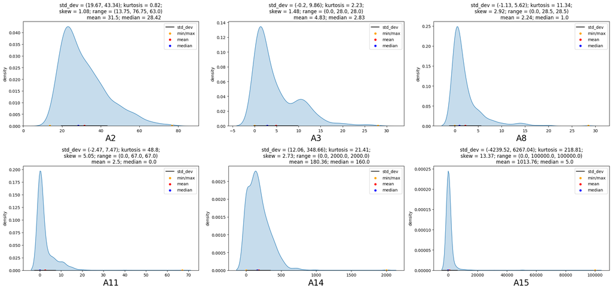

```python
eda_overview.UVA_numeric(data = df2, var_group = contAttr)
```

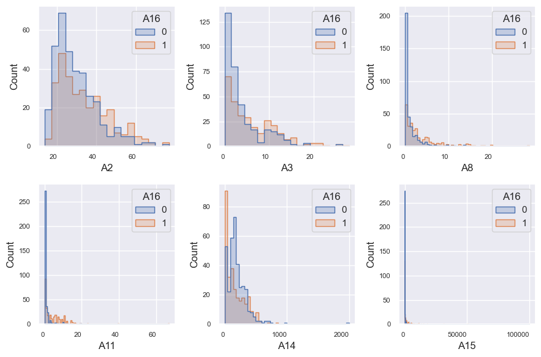

```python
# Apply the default theme
sns.set_theme()
t = eda_overview.UVA_numeric_classwise(df2, 'A16', ['A16'],
                                       colcount = 3, colwidth = 3,
                                       rowheight = 3,
                                       plot_type = 'histogram', element = 'step')

plt.gcf().savefig(path+'Numeric_interaction_class.png', dpi = 150)
```

```python
t = eda_overview.distribution_comparison(df2, 'A16',['A16'])[0]
t
```

| Value A16 category Continous Attributes | Maximum 0 | Maximum 1 | Minimum 0 | Minimum 1 | Range 0 | Range 1 | Standard Deviation 0 | Standard Deviation 1 | Unique Value count 0 | Unique Value count 1 |
| --- | --- | --- | --- | --- | --- | --- | --- | --- | --- | --- |
| A2 | 74.830 | 76.75 | 15.17 | 13.75 | 59.660 | 63.0 | 10.7192 | 12.6894 | 222 | 219 |
| A3 | 26.335 | 28.00 | 0.00 | 0.00 | 26.335 | 28.0 | 4.3931 | 5.4927 | 146 | 146 |
| A8 | 13.875 | 28.50 | 0.00 | 0.00 | 13.875 | 28.5 | 2.0293 | 4.1674 | 67 | 117 |
| A11 | 20.000 | 67.00 | 0.00 | 0.00 | 20.000 | 67.0 | 1.9584 | 6.3981 | 12 | 23 |
| A14 | 2000.000 | 840.00 | 0.00 | 0.00 | 2000.000 | 840.0 | 172.0580 | 162.5435 | 100 | 108 |
| A15 | 5552.000 | 100000.00 | 0.00 | 0.00 | 5552.000 | 100000.0 | 632.7817 | 7660.9492 | 110 | 145 |

```python
t.to_csv(path +'NumericDistributionComparison.csv')
```

```python
# Inspecting number of unique values
df2[contAttr].nunique()
```

```
A2     340
A3     213
A8     131
A11     23
A14    164
A15    229
dtype: int64
```

# Bivariate Analysis - Continous Variables

Findings from the correlation plot are as below :

```python
# Continous Variables are A2, A3, A11, A14, A15
contAttr = ['A2', 'A3','A8', 'A11', 'A14', 'A15']

# Target Variable is A16
targetAttr = ['A16']
```

```python
df2[contAttr+targetAttr]
```

|  | A2 | A3 | A8 | A11 | A14 | A15 | A16 |
| --- | --- | --- | --- | --- | --- | --- | --- |
| 0 | 30.83 | 0.000 | 1.25 | 1.0 | 202.0 | 0.0 | 1 |
| 1 | 58.67 | 4.460 | 3.04 | 6.0 | 43.0 | 560.0 | 1 |
| 2 | 24.50 | 0.500 | 1.50 | 0.0 | 280.0 | 824.0 | 1 |
| 3 | 27.83 | 1.540 | 3.75 | 5.0 | 100.0 | 3.0 | 1 |
| 4 | 20.17 | 5.625 | 1.71 | 0.0 | 120.0 | 0.0 | 1 |
| ... | ... | ... | ... | ... | ... | ... | ... |
| 685 | 21.08 | 10.085 | 1.25 | 0.0 | 260.0 | 0.0 | 0 |
| 686 | 22.67 | 0.750 | 2.00 | 2.0 | 200.0 | 394.0 | 0 |
| 687 | 25.25 | 13.500 | 2.00 | 1.0 | 200.0 | 1.0 | 0 |
| 688 | 17.92 | 0.205 | 0.04 | 0.0 | 280.0 | 750.0 | 0 |
| 689 | 35.00 | 3.375 | 8.29 | 0.0 | 0.0 | 0.0 | 0 |

653 rows × 7 columns

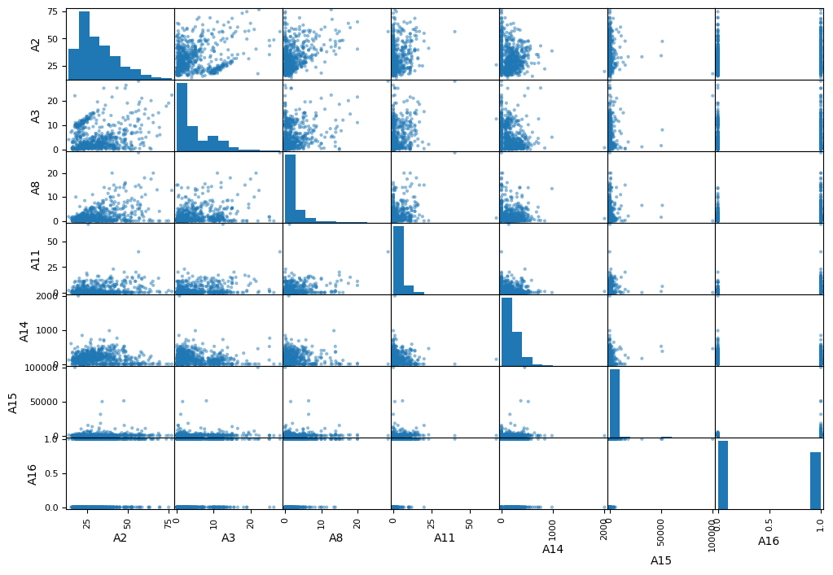

```python
# Bivariate analysis at overall level

plt.rcdefaults()
#sns.set('notebook')
#sns.set_theme(style = 'whitegrid')
sns.set_context(font_scale = 0.6)
from pandas.plotting import scatter_matrix
scatter_matrix(df2[contAttr+targetAttr], figsize = (12,8));
```

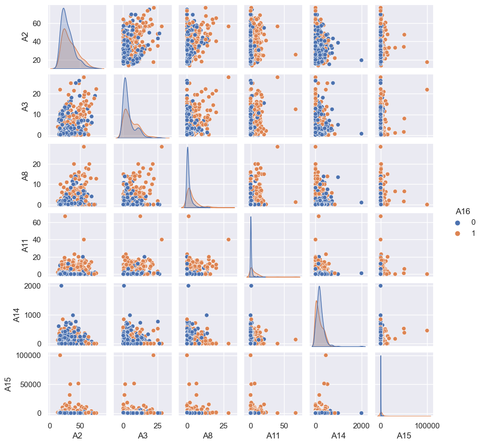

```python
# Bivariate analysis taking into account the target categories

#sns.set('notebook')
sns.set_theme(style="darkgrid")
sns.pairplot(df2[contAttr+targetAttr],hue= 'A16',height = 1.5)
```

```python
df2[contAttr+targetAttr].dtypes
```

```
A2     float64
A3     float64
A8     float64
A11    float64
A14    float64
A15    float64
A16      int64
dtype: object
```

```python
# Correlation table
df2[contAttr].corr()
```

|  | A2 | A3 | A8 | A11 | A14 | A15 |
| --- | --- | --- | --- | --- | --- | --- |
| A2 | 1.0000 | 0.2177 | 0.4176 | 0.1982 | -0.0846 | 0.0291 |
| A3 | 0.2177 | 1.0000 | 0.3006 | 0.2698 | -0.2171 | 0.1198 |
| A8 | 0.4176 | 0.3006 | 1.0000 | 0.3273 | -0.0648 | 0.0522 |
| A11 | 0.1982 | 0.2698 | 0.3273 | 1.0000 | -0.1161 | 0.0584 |
| A14 | -0.0846 | -0.2171 | -0.0648 | -0.1161 | 1.0000 | 0.0734 |
| A15 | 0.0291 | 0.1198 | 0.0522 | 0.0584 | 0.0734 | 1.0000 |

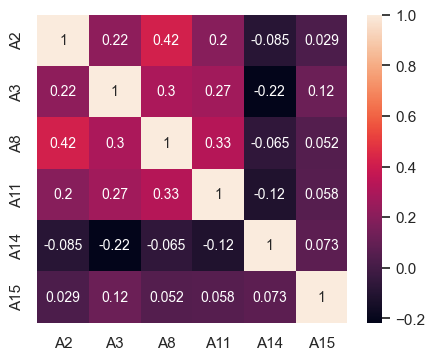

```python
# Heatmap for correlation of numeric attributes
fig, ax = plt.subplots(figsize=(5,4))
sns.heatmap(df2[contAttr].corr(), annot = True, ax = ax, annot_kws={"fontsize":10});
```

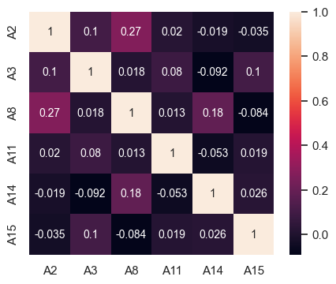

```python
# Correlation matrix for customers not granted credit
fig, ax = plt.subplots(figsize=(5,4))
sns.heatmap(df2[df2['A16'] == 0][contAttr].corr(), ax = ax, annot_kws={"fontsize":10}, annot = True);
```

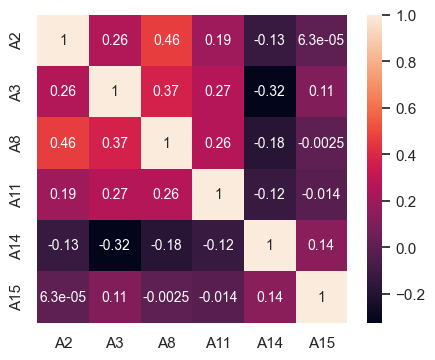

```python
# Correlation matrix for customers granted credit
fig, ax = plt.subplots(figsize=(5,4))
sns.heatmap(df2[df2['A16'] == 1][contAttr].corr(),ax = ax,
            annot_kws={"fontsize":10}, annot = True);
```

# Univariate Analysis - Categorical Variables

```python
# Continous Variables are A2, A3, A8, A11, A14, A15
# Categorical Input Variables are A1, A4, A5, A6, A7, A9, A10, A12, A13
# Target Variable is A16 and is categorical.

catAttr = ["A1","A4", "A5", "A6", "A7", "A9", "A10", "A12", "A13"]
```

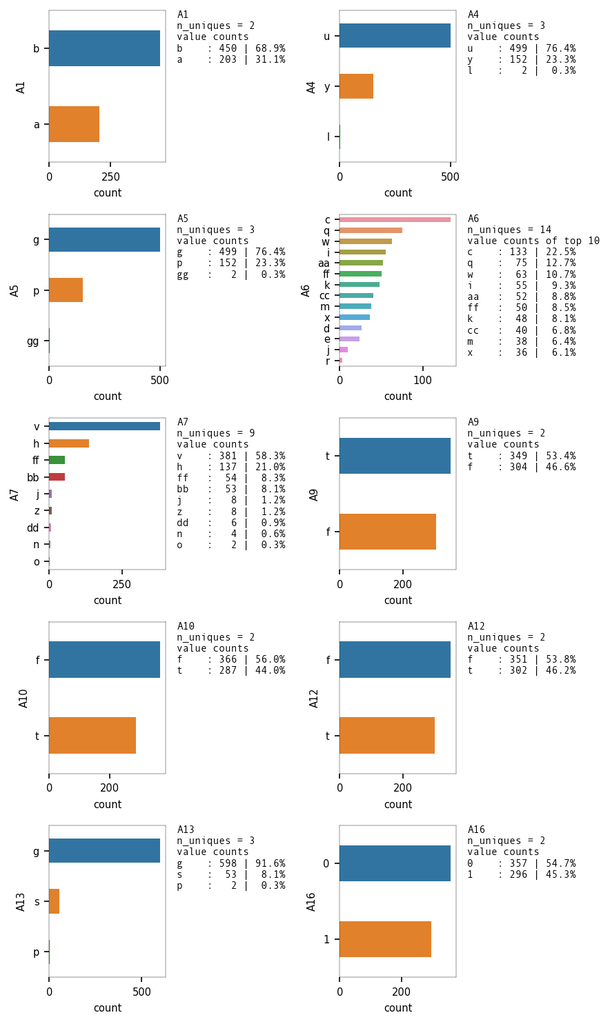

```python
eda_overview.UVA_category(df2, var_group = catAttr + targetAttr,
                          colwidth = 3,
                          rowheight = 2,
                          colcount = 2,
                          spine_linewidth = 0.2,
                          nspaces = 4, ncountspaces = 3,
                          axlabel_fntsize = 7,
                          ax_xticklabel_fntsize = 7,
                          ax_yticklabel_fntsize = 7,
                          change_ratio = 0.6,
                          infofntsize = 7)
```

## Distribution of the Target Class

Dataset is balanced as the ratio of the binary classes is ~55:45.  
We can use **Accuracy as a Evaluation metric** for the classifier model.

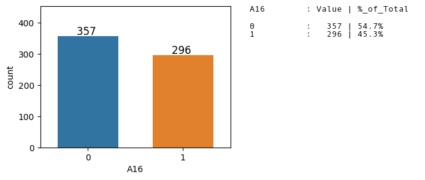

```python
plt.figure(figsize = (4,3), dpi = 100)
ax = sns.countplot(x = 'A16', data = df2, )
ax.set_ylim(0, 1.1*ax.get_ylim()[1])

axes_utils.Add_data_labels(ax.patches)
axes_utils.Change_barWidth(ax.patches, 0.8)
axes_utils.Add_valuecountsinfo(ax, 'A16',df2)
```

# Train Test Split the dataset

```python
X, y = df2.drop(targetAttr, axis = 1), df2['A16']
```

```python
# Train test split
X_train, X_test, y_train, y_test = train_test_split(X, y, random_state=42, stratify = y)
```

```python
print("X_train shape : {}".format(X_train.shape))
print("X_test shape : {}".format(X_test.shape))
print("y_train shape : {}".format(y_train.shape))
print("y_test shape : {}".format(y_test.shape))
```

```
X_train shape : (489, 15)
X_test shape : (164, 15)
y_train shape : (489,)
y_test shape : (164,)
```

```python
X_train.head()
```

|  | A1 | A2 | A3 | A4 | A5 | A6 | A7 | A8 | A9 | A10 | A11 | A12 | A13 | A14 | A15 |
| --- | --- | --- | --- | --- | --- | --- | --- | --- | --- | --- | --- | --- | --- | --- | --- |
| 7 | a | 22.92 | 11.585 | u | g | cc | v | 0.040 | t | f | 0.0 | f | g | 80.0 | 1349.0 |
| 64 | b | 26.67 | 4.250 | u | g | cc | v | 4.290 | t | t | 1.0 | t | g | 120.0 | 0.0 |
| 320 | b | 21.25 | 1.500 | u | g | w | v | 1.500 | f | f | 0.0 | f | g | 150.0 | 8.0 |
| 358 | b | 32.42 | 3.000 | u | g | d | v | 0.165 | f | f | 0.0 | t | g | 120.0 | 0.0 |
| 628 | b | 29.25 | 13.000 | u | g | d | h | 0.500 | f | f | 0.0 | f | g | 228.0 | 0.0 |

# Transformation Pipelines

```python
# Creating numeric Pipeline for standard scaling of numeric features

from sklearn.pipeline import Pipeline
from sklearn.preprocessing import StandardScaler

num_pipeline = Pipeline([
    ('std_scaler', StandardScaler())])
```

```python
from sklearn import set_config

set_config(display="diagram")
num_pipeline
```

```
Pipeline(steps=[('std_scaler', StandardScaler())])
```

```python
df2_num_tr = num_pipeline.fit_transform(df2[contAttr])
pd.DataFrame(df2_num_tr)
```

|  | 0 | 1 | 2 | 3 | 4 | 5 |
| --- | --- | --- | --- | --- | --- | --- |
| 0 | -0.0570 | -0.9614 | -0.2952 | -0.3026 | 0.1287 | -0.1931 |
| 1 | 2.2965 | -0.0736 | 0.2362 | 0.7045 | -0.8168 | -0.0864 |
| 2 | -0.5921 | -0.8619 | -0.2210 | -0.5040 | 0.5925 | -0.0362 |
| 3 | -0.3106 | -0.6549 | 0.4470 | 0.5031 | -0.4779 | -0.1926 |
| 4 | -0.9581 | 0.1584 | -0.1586 | -0.5040 | -0.3589 | -0.1931 |
| ... | ... | ... | ... | ... | ... | ... |
| 648 | -0.8812 | 1.0462 | -0.2952 | -0.5040 | 0.4736 | -0.1931 |
| 649 | -0.7468 | -0.8121 | -0.0725 | -0.1012 | 0.1168 | -0.1181 |
| 650 | -0.5287 | 1.7261 | -0.0725 | -0.3026 | 0.1168 | -0.1929 |
| 651 | -1.1483 | -0.9206 | -0.6544 | -0.5040 | 0.5925 | -0.0502 |
| 652 | 0.2956 | -0.2896 | 1.7948 | -0.5040 | -1.0725 | -0.1931 |

653 rows × 6 columns

```python
# Transforming the X_train and X_test
```

```python
from sklearn.compose import ColumnTransformer
from sklearn.preprocessing import OneHotEncoder

# Segregating the numeric and categorical features
num_attribs = ['A2', 'A3','A8', 'A11', 'A14', 'A15']
cat_attribs = ["A1","A4", "A5", "A6", "A7", "A9", "A10", "A12", "A13"]

# Creating Column Transformer for selectively applying tranformations
# both standard scaling and one hot encoding
full_pipeline = ColumnTransformer([
    ("num", num_pipeline, num_attribs),
    ("cat", OneHotEncoder(handle_unknown='ignore'), cat_attribs)])

# Creating Column Transformer for selectively applying tranformations
# only one hot encoding and no standard scaling
categorical_pipeline = ColumnTransformer([
    ("num_selector", "passthrough", num_attribs),
    ("cat", OneHotEncoder(handle_unknown='ignore'), cat_attribs)])
```

```python
# Displaying the full_pipeline
from sklearn import set_config

set_config(display="diagram")
full_pipeline
```

```
ColumnTransformer(transformers=[('num',
                                 Pipeline(steps=[('std_scaler',
                                                  StandardScaler())]),
                                 ['A2', 'A3', 'A8', 'A11', 'A14', 'A15']),
                                ('cat', OneHotEncoder(handle_unknown='ignore'),
                                 ['A1', 'A4', 'A5', 'A6', 'A7', 'A9', 'A10',
                                  'A12', 'A13'])])
```

```python
# Displaying the categorical_pipeline
from sklearn import set_config

set_config(display="diagram")
categorical_pipeline
```

```
ColumnTransformer(transformers=[('num_selector', 'passthrough',
                                 ['A2', 'A3', 'A8', 'A11', 'A14', 'A15']),
                                ('cat', OneHotEncoder(handle_unknown='ignore'),
                                 ['A1', 'A4', 'A5', 'A6', 'A7', 'A9', 'A10',
                                  'A12', 'A13'])])
```

```python
# Learning the parameters for transforming from train set using full_pipeline
# Transforming both train and test set
X_train_tr1 = full_pipeline.fit_transform(X_train)
X_test_tr1 = full_pipeline.transform(X_test)
```

```python
# Learning the parameters for transforming from train set using categorical pipeline
# Transforming both train and test set
X_train_tr2 = categorical_pipeline.fit_transform(X_train)
X_test_tr2 = categorical_pipeline.transform(X_test)
```

```python
# Transforming the target variable
```

```python
from sklearn.preprocessing import LabelEncoder

# prepare input data
def prepare_targets(y_train, y_test):
    le = LabelEncoder()
    le.fit(np.ravel(y_train))
    y_train_enc = le.transform(np.ravel(y_train))
    y_test_enc = le.transform(np.ravel(y_test))

    return y_train_enc, y_test_enc
```

```python
y_train_tr, y_test_tr = prepare_targets(y_train, y_test)
```

# Training and Testing Models

```python
# Function for returning a string containing
# Classification report and the accuracy, precision, recall and F1 measures on train and test data
# The average parameter for the measures is 'macro' as the minority class is of importance.

from sklearn.metrics import recall_score, precision_score, accuracy_score, \
    confusion_matrix, ConfusionMatrixDisplay, classification_report, f1_score, \
    roc_curve, auc

def evaluation_parametrics(y_train,yp_train,y_test,yp_test,average_param = 'weighted'):
    '''
    average_param : values can be 'weighted', 'micro', 'macro'.
    Check link:
    https://scikit-learn.org/stable/modules/model_evaluation.html#scoring-parameter
    https://scikit-learn.org/stable/modules/classes.html#module-sklearn.metrics
    https://scikit-learn.org/stable/modules/generated/sklearn.metrics.precision_score.html#sklearn.metrics.precision_score
    '''
    d = 2
    txt = "-"*60 \
    + "\nClassification Report for Train Data\n" \
    + classification_report(y_train, yp_train) \
    + "\nClassification Report for Test Data\n" \
    + classification_report(y_test, yp_test) \
    + "\n" + "-"*60 + "\n" \
    + "Accuracy on Train Data is: {}".format(round(accuracy_score(y_train,yp_train),d)) \
    + '\n' \
    + "Accuracy on Test Data is: {}".format(round(accuracy_score(y_test,yp_test),d)) \
    + "\n" + "-"*60 + "\n" \
    + "Precision on Train Data is: {}".format(round(precision_score(y_train,yp_train,average = average_param),d)) \
    + "\n" \
    + "Precision on Test Data is: {}".format(round(precision_score(y_test,yp_test,average = average_param),d)) \
    + "\n" + "-"*60 + "\n" \
    + "Recall on Train Data is: {}".format(round(recall_score(y_train,yp_train,average = average_param),d)) \
    + "\n" \
    + 'Recall on Test Data is: {}'.format(round(recall_score(y_test,yp_test,average = average_param),d)) \
    + "\n" + "-"*60 + "\n" \
    + "F1 Score on Train Data is: {}".format(round(f1_score(y_train,yp_train,average = average_param),d)) \
    + "\n" \
    + "F1 Score on Test Data is: {}".format(round(f1_score(y_test,yp_test,average = average_param),d)) \
    + "\n" + "-"*60 + "\n"
    return txt
```

```python
def Confusion_matrix_ROC_AUC(name, alias, pipeline,
                             X_train_tr, y_train_tr,
                             X_test_tr,y_test_tr):
    '''
    This function reurns three plots :
        - Confusion matrix on testset predictions
        - Classification report for performance on train and test set
        - roc and auc curve for test set predictions

    The arguments are :
        name : short/terse name for the composite estimator
        alias : descriptive name for the composite estimator
        pipeline : Composite estimator
        X_train_tr, y_train_tr : train set feature matrix, train set target
        X_test_tr,y_test_tr : test set feature matrix, test set target

    For reference, below is a list containing the tuple of (name, alias, pipeline)
          [('SGD', 'Stochastic Gradient Classifier',SGDClassifier(random_state=42)),
          ('LR','Logistic Regression Classifier', LogisticRegression(max_iter = 1000,random_state = 48)),
          ('RF','Random Forest Classifier', RandomForestClassifier(max_depth=2, random_state=42)),
          ('KNN','KNN Classifier',KNeighborsClassifier(n_neighbors = 7)),
          ('NB','Naive Bayes Classifier', GaussianNB()),
          ('SVC','Support Vector Classifier',
          `LinearSVC(class_weight='balanced', verbose=False, max_iter=10000, tol=1e-4, C=0.1)),
          ('CART', 'CART', DecisionTreeClassifier(max_depth = 7,random_state = 48)),
          ('GBM','Gradient Boosting Classifier',
           GradientBoostingClassifier(n_estimators=50, max_depth=10)),
          ('LDA', 'LDA Classifier', LinearDiscriminantAnalysis())]

    For instance, if the classifier is an SGDClassifier, the suggested name and alias are :
    'SGD'/'sgdclf', 'Stochastic Gradient Classifier'.

    It is recommended to adhere to name and alias conventions,
        - as the name argument is used to for checking whether calibrated Classifier CV is required or not.
        - as the alias argument will be used as title in the Classification report plot.

    Call the functions : evaluation_parametrics
    Check the links :
        https://peps.python.org/pep-0008/#maximum-line-length
        https://scikit-learn.org/stable/glossary.html#term-predict_proba

    Example :
        >> Confusion_matrix_ROC_AUC('sgd_clf','Stochastic Gradient Classifier',sgd_clf,
                                    X_train_tr, y_train_tr, X_test_tr,y_test_tr)

    '''
    from sklearn.metrics import recall_score, precision_score, accuracy_score, \
    confusion_matrix, ConfusionMatrixDisplay, classification_report, f1_score, \
    roc_curve, auc

    from sklearn.calibration import CalibratedClassifierCV

    fig = plt.figure(figsize=(10,5), dpi = 130)
    gridsize = (2, 3)
    ax1 = plt.subplot2grid(gridsize, (0, 0), colspan=1, rowspan=1)
    ax2 = plt.subplot2grid(gridsize, (0, 1), colspan = 2, rowspan = 2)
    ax3 = plt.subplot2grid(gridsize, (1, 0), colspan = 1)

    sns.set(font_scale=0.75) # Adjust to fit
    #---------------------------------------------------------------------------------
    # Displaying the confusion Matrix

    #ax1 = fig.add_subplot(1,3,2)

    # Fitting the model
    model = pipeline
    model.fit(X_train_tr, y_train_tr)

    # Predictions on train and test set
    yp_train_tr = model.predict(X_train_tr)
    yp_test_tr = model.predict(X_test_tr)

    # Creating the confusion matrix for test set results
    cm = confusion_matrix(y_test_tr, yp_test_tr, labels= pipeline.classes_)
    disp = ConfusionMatrixDisplay(confusion_matrix=cm, display_labels= pipeline.classes_)

    ax1.grid(False)
    disp.plot(ax = ax1)
    ax1.set_title('Confusion Matrix on testset pred')


    #---------------------------------------------------------------------------------
    # Displaying the evaluation results that include the classification report
    #ax2 = fig.add_subplot(1,3,2)

    eval_results = (str(alias) \
                    +'\n' \
                    + evaluation_parametrics(y_train_tr,yp_train_tr,
                                             y_test_tr,yp_test_tr))

    ax2.annotate(xy = (0,1), text = eval_results, size = 8,
                 ha = 'left', va = 'top', font = 'Andale Mono')
    ax2.patch.set(visible = False)
    ax2.tick_params(top=False, bottom=False, left=False, right=False,
                    labelleft=False, labelbottom=False)
    #ax2.ticks.off

    #---------------------------------------------------------------------------------
    # Displaying the ROC AUC curve
    import re
    pattern = re.compile('(sgd|SGD|SVC)')
    if re.search(pattern, name) :
        print('Calibrated Classifier CV needed.')
        #base_model = SGDClassifier()
        model = CalibratedClassifierCV(pipeline)
    else :
        print('Calibrated Classifier CV not needed.')
        model = pipeline

    # Fitting the model
    model.fit(X_train_tr, y_train_tr)

    #https://scikit-learn.org/stable/glossary.html#term-predict_proba
    preds = model.predict_proba(X_test_tr)
    pred = pd.Series(preds[:,1])

    fpr, tpr, thresholds = roc_curve(y_test_tr, pred)
    auc_score = auc(fpr, tpr)
    label='%s: auc=%f' % (name, auc_score)

    ax3.plot(fpr, tpr, linewidth=1)
    ax3.fill_between(fpr, tpr,  label = label, linewidth=1, alpha = 0.1, ec = 'black')
    ax3.plot([0, 1], [0, 1], 'k--') #x=y line.
    ax3.set_xlim([0.0, 1.0])
    ax3.set_ylim([0.0, 1.05])
    ax3.set_xlabel('False Positive Rate')
    ax3.set_ylabel('True Positive Rate')
    ax3.set_title('ROC curve')
    ax3.legend(loc = 'lower right')

    fig.tight_layout()
    plt.show()
    return fig
```

```python
# Creating a dictionary to store the performace measures on train and test data
# Note the precion, recall and F1 score measures are weighted averages taking into consideration the class sizes

def create_dict(model, modelname, y_train, yp_train, y_test, yp_test, average_param = 'weighted'):
    '''
    average_param : values can be 'weighted', 'micro', 'macro'.
    Check link:
            https://scikit-learn.org/stable/modules/model_evaluation.html#scoring-parameter
            https://scikit-learn.org/stable/modules/classes.html#module-sklearn.metrics
            https://scikit-learn.org/stable/modules/generated/sklearn.metrics.precision_score.html
            #sklearn.metrics.precision_score

    '''
    d = 4
    dict1 = {modelname :  {"Accuracy":{"Train": float(np.round(accuracy_score(y_train,yp_train), d)),
                                       "Test": float(np.round(accuracy_score(y_test,yp_test),d))},
                           "F1" : {"Train":
                                   float(np.round(f1_score(y_train,yp_train,average = average_param),d)),
                                  "Test":
                                   float(np.round(f1_score(y_test,yp_test,average = average_param),d))},
                           "Recall": {"Train":
                                      float(np.round(recall_score(y_train,yp_train,average = average_param),d)),
                                      "Test":
                                      float(np.round(recall_score(y_test,yp_test,average = average_param),d))},
                           "Precision" :{"Train":
                                         float(np.round(precision_score(y_train,yp_train,average = average_param),d)),
                                         "Test":
                                         float(np.round(precision_score(y_test,yp_test,average = average_param),d))
                                       }}
            }
    return dict1

dict_perf = {}
```

```python
# Display the performance measure outputs for all the classifiers
# unpacking the dictionary to dataframe

def display_results(dict_perf):
    pd.set_option('precision', 4)
    user_ids = []
    frames = []
    for user_id, d in dict_perf.items():
        user_ids.append(user_id)
        frames.append(pd.DataFrame.from_dict(d, orient='columns'))

    df = pd.concat(frames, keys=user_ids)
    df = df.unstack(level = -1)
    return df
```

## Stochastic Gradient Descent Classifier

```
Total time: 0.01s
Calibrated Classifier CV needed.
```

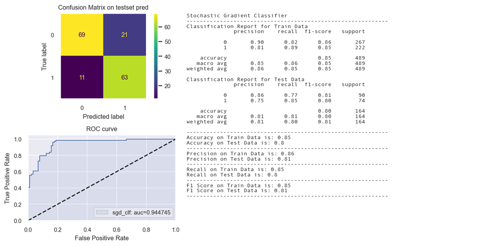

```python
from sklearn.linear_model import SGDClassifier
from sklearn.calibration import CalibratedClassifierCV

name = 'sgdclf'
sgd_clf = SGDClassifier(random_state=42)

st_time = time.time()
sgd_clf.fit(X_train_tr1, y_train_tr)

yp_train_tr = sgd_clf.predict(X_train_tr1)
yp_test_tr = sgd_clf.predict(X_test_tr1)

en_time = time.time()
print('Total time: {:.2f}s'.format(en_time-st_time))

#print(evaluation_parametrics(y_train_tr,yp_train_tr,y_test_tr,yp_test_tr,average_param = 'weighted'))

dict1 = create_dict(sgd_clf, "SGD Classifier",
                    y_train_tr, yp_train_tr, y_test_tr, yp_test_tr)
dict_perf.update(dict1)

sns.set(font_scale=0.75)
fig = Confusion_matrix_ROC_AUC('sgd_clf','Stochastic Gradient Classifier',
                         sgd_clf, X_train_tr1, y_train_tr,X_test_tr1,y_test_tr)

fig.savefig(path+'StochasticGradientClassifier.png', dpi = 150)
```

## Logistic Regression Classifier

```
Total time: 0.02s
Calibrated Classifier CV not needed.
```

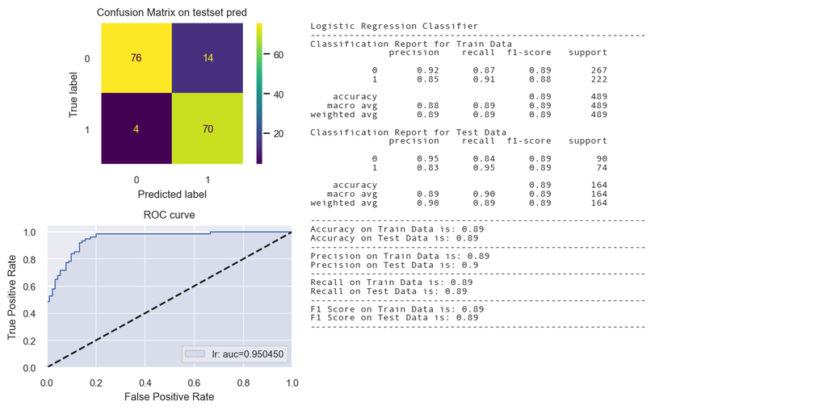

```python
lr = LogisticRegression(max_iter = 1000,random_state = 48)

st_time = time.time()
lr.fit(X_train_tr1, y_train_tr)

yp_train_tr = lr.predict(X_train_tr1)
yp_test_tr = lr.predict(X_test_tr1)

en_time = time.time()
print('Total time: {:.2f}s'.format(en_time-st_time))

#print(evaluation_parametrics(y_train_tr,yp_train_tr,y_test_tr,yp_test_tr))

dict1 = create_dict(lr, "Logistic Regression Classifier", y_train_tr, yp_train_tr, y_test_tr, yp_test_tr)
dict_perf.update(dict1)

fig = Confusion_matrix_ROC_AUC('lr','Logistic Regression Classifier',lr, X_train_tr1, y_train_tr,X_test_tr1,y_test_tr)
```

## Random Forest Classifier

```
Total time: 0.15s
Calibrated Classifier CV not needed.
```

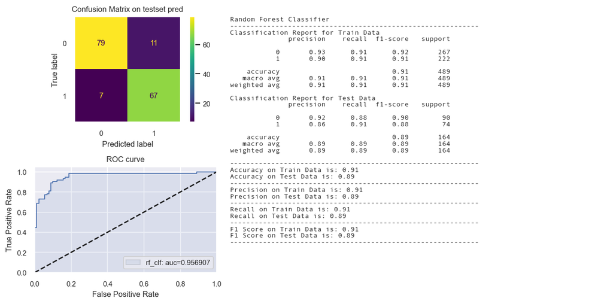

```python
rf_clf = RandomForestClassifier(max_depth=5, random_state=42)

st_time = time.time()
rf_clf.fit(X_train_tr2, y_train_tr)

yp_train_tr = rf_clf.predict(X_train_tr2)
yp_test_tr = rf_clf.predict(X_test_tr2)

en_time = time.time()
print('Total time: {:.2f}s'.format(en_time-st_time))

#print(evaluation_parametrics(y_train_tr,yp_train_tr,y_test_tr,yp_test_tr))

dict1 = create_dict(rf_clf, "Random Forest Classifier",
                    y_train_tr, yp_train_tr, y_test_tr, yp_test_tr)
dict_perf.update(dict1)

fig = Confusion_matrix_ROC_AUC('rf_clf','Random Forest Classifier',rf_clf,
                         X_train_tr2, y_train_tr,X_test_tr2,y_test_tr)
```

## KNN Classifier

```
Total time: 0.03s
Calibrated Classifier CV not needed.
```

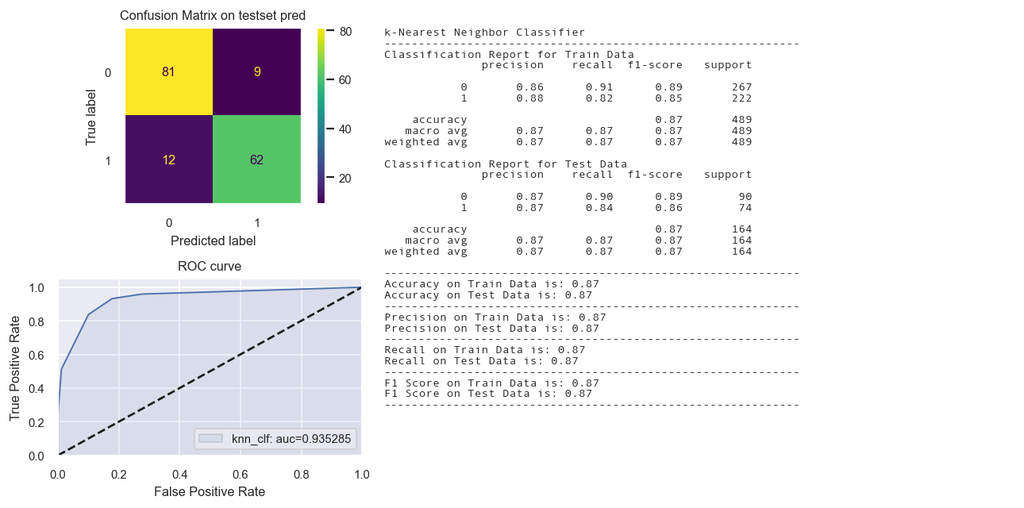

```python
# training a KNN classifier
knn_clf = KNeighborsClassifier(n_neighbors = 7)

st_time = time.time()
knn_clf.fit(X_train_tr1, y_train_tr)

yp_train_tr = knn_clf.predict(X_train_tr1)
yp_test_tr = knn_clf.predict(X_test_tr1)

en_time = time.time()
print('Total time: {:.2f}s'.format(en_time-st_time))

#print(evaluation_parametrics(y_train_tr,yp_train_tr,y_test_tr,yp_test_tr))

dict1 = create_dict(knn_clf, "k-Nearest Neighbor Classifier", y_train_tr, yp_train_tr, y_test_tr, yp_test_tr)
dict_perf.update(dict1)

fig = Confusion_matrix_ROC_AUC('knn_clf', "k-Nearest Neighbor Classifier",knn_clf,
                         X_train_tr1, y_train_tr,X_test_tr1,y_test_tr)
```

## Naive Bayes Classifier

```
Total time: 0.00s
Calibrated Classifier CV not needed.
```

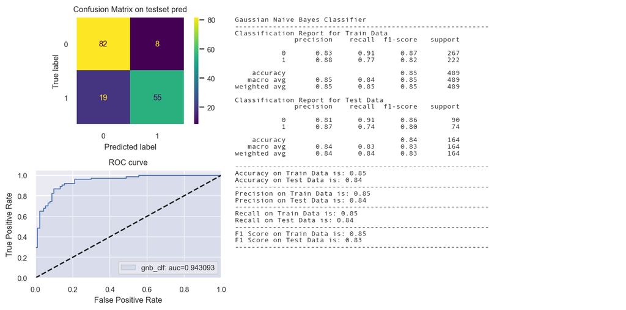

```python
# training a Naive Bayes classifier
from sklearn.naive_bayes import GaussianNB
gnb_clf = GaussianNB()

st_time = time.time()
gnb_clf.fit(X_train_tr2, y_train_tr)

yp_train_tr = gnb_clf.predict(X_train_tr2)
yp_test_tr = gnb_clf.predict(X_test_tr2)

en_time = time.time()
print('Total time: {:.2f}s'.format(en_time-st_time))

#print(evaluation_parametrics(y_train_tr,yp_train_tr,y_test_tr,yp_test_tr))

dict1 = create_dict(gnb_clf, "Gaussian Naive Bayes Classifier", y_train_tr, yp_train_tr, y_test_tr, yp_test_tr)
dict_perf.update(dict1)

fig = Confusion_matrix_ROC_AUC('gnb_clf', "Gaussian Naive Bayes Classifier",gnb_clf,
                         X_train_tr2, y_train_tr,X_test_tr2,y_test_tr)
```

## Linear Support Vector Classifier

```
Total time: 0.01s
Calibrated Classifier CV needed.
```

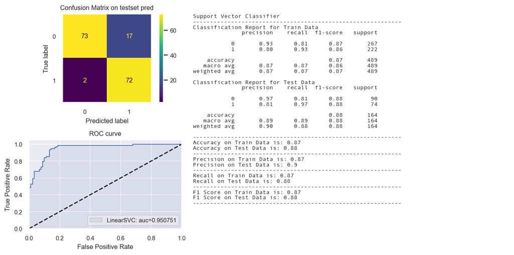

```python
svm = LinearSVC(class_weight='balanced', verbose=False, max_iter=10000, tol=1e-4, C=0.1)

st_time = time.time()
svm.fit(X_train_tr1,y_train_tr)

yp_train_tr = svm.predict(X_train_tr1)
yp_test_tr = svm.predict(X_test_tr1)

en_time = time.time()
print('Total time: {:.2f}s'.format(en_time-st_time))

#print(evaluation_parametrics(y_train_tr,yp_train_tr,y_test_tr,yp_test_tr))

dict1 = create_dict(svm, "Support Vector Classifier", y_train_tr, yp_train_tr, y_test_tr, yp_test_tr)
dict_perf.update(dict1)

fig = Confusion_matrix_ROC_AUC('LinearSVC', "Support Vector Classifier",svm,
                         X_train_tr1, y_train_tr,X_test_tr1,y_test_tr)
```

## Decision Tree Classifier

```
Total time: 0.53s
Calibrated Classifier CV not needed.
```

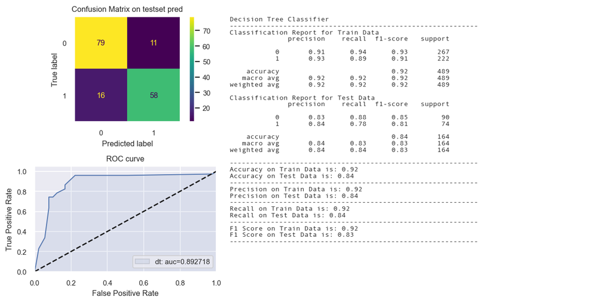

```python
dt = DecisionTreeClassifier(max_depth = 5,random_state = 48)
# Keeping max_depth = 7 to avoid overfitting
dt.fit(X_train_tr2,y_train_tr)

yp_train_tr = dt.predict(X_train_tr2)
yp_test_tr = dt.predict(X_test_tr2)

en_time = time.time()
print('Total time: {:.2f}s'.format(en_time-st_time))

#print(evaluation_parametrics(y_train_tr,yp_train_tr,y_test_tr,yp_test_tr))

dict1 = create_dict(dt, "Decision Tree Classifier", y_train_tr, yp_train_tr, y_test_tr, yp_test_tr)
dict_perf.update(dict1)

fig = Confusion_matrix_ROC_AUC('dt', "Decision Tree Classifier", dt,
                         X_train_tr2, y_train_tr,X_test_tr2,y_test_tr)
```

## Gradient Boosting Model

```
Total time: 0.11s
Calibrated Classifier CV not needed.
```

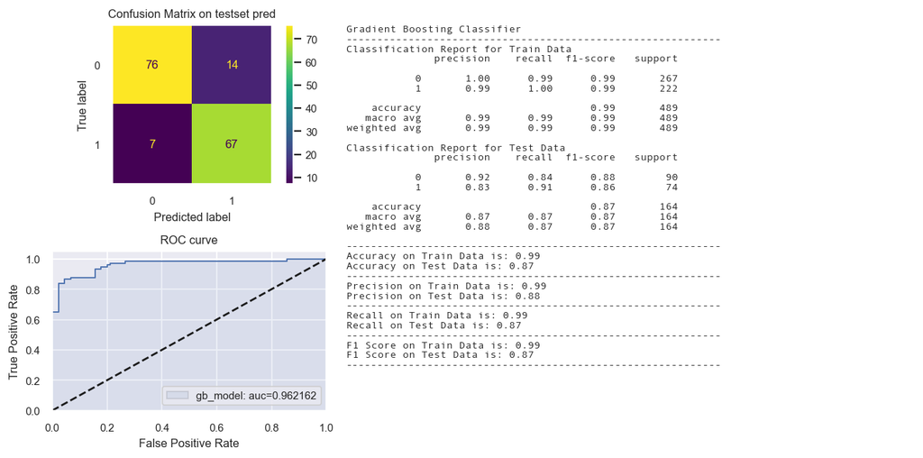

```python
gb_model = GradientBoostingClassifier(n_estimators=50, max_depth=5)

st_time = time.time()
gb_model.fit(X_train_tr2,y_train_tr)

yp_train_tr = gb_model.predict(X_train_tr2)
yp_test_tr = gb_model.predict(X_test_tr2)

en_time = time.time()
print('Total time: {:.2f}s'.format(en_time-st_time))

#print(evaluation_parametrics(y_train_tr,yp_train_tr,y_test_tr,yp_test_tr))

dict1 = create_dict(gb_model, "Gradient Boosting Classifier", y_train_tr, yp_train_tr, y_test_tr, yp_test_tr)
dict_perf.update(dict1)


fig = Confusion_matrix_ROC_AUC('gb_model', "Gradient Boosting Classifier", gb_model,
                         X_train_tr2, y_train_tr,X_test_tr2,y_test_tr)
```

## Linear Discriminant Analysis Model

```
Calibrated Classifier CV not needed.
```

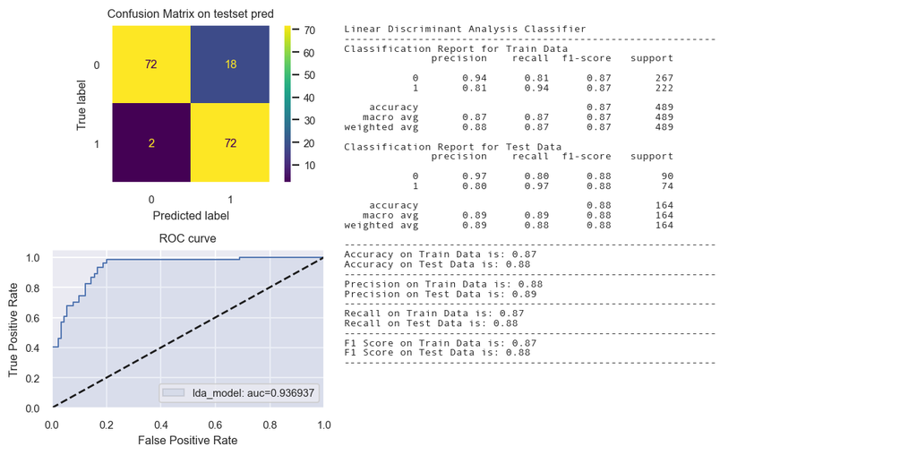

```python
lda_model = LinearDiscriminantAnalysis()

st_time = time.time()
lda_model.fit(X_train_tr1,y_train_tr)

yp_train_tr = lda_model.predict(X_train_tr1)
yp_test_tr = lda_model.predict(X_test_tr1)

en_time = time.time()
#print('Total time: {:.2f}s'.format(en_time-st_time))

evaluation_parametrics(y_train_tr,yp_train_tr,y_test_tr,yp_test_tr)

dict1 = create_dict(lda_model, "Linear Discriminant Analysis Classifier",
                    y_train_tr, yp_train_tr, y_test_tr, yp_test_tr)
dict_perf.update(dict1)

fig = Confusion_matrix_ROC_AUC('lda_model', "Linear Discriminant Analysis Classifier", lda_model,
                         X_train_tr1, y_train_tr,X_test_tr1,y_test_tr)
```

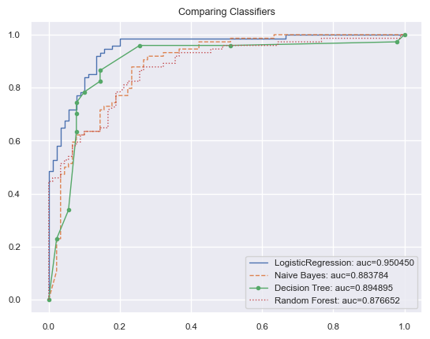

```python
from matplotlib import pyplot as plt
import sklearn
from sklearn.metrics import roc_curve, auc
#from sklearn.cross_validation import train_test_split
from sklearn.linear_model import LogisticRegression
from sklearn.tree import DecisionTreeClassifier
from sklearn.ensemble import RandomForestClassifier
from sklearn.naive_bayes import GaussianNB

# name -> (line format, classifier)
CLASS_MAP = {
    'LogisticRegression':('-', LogisticRegression()),
    'Naive Bayes': ('--', GaussianNB()),
    'Decision Tree':('.-', DecisionTreeClassifier(max_depth=5)),
    'Random Forest':(':', RandomForestClassifier( max_depth=5, n_estimators=10, max_features=1)),
}

# Divide cols by independent/dependent, rows by test/ train
#X, Y = df[df.columns[:3]], (df['species']=='virginica') X_train, X_test, Y_train, Y_test = \
#train_test_split(X, Y, test_size=.8)

#X_train_tr, y_train_tr,X_test_tr,y_test_tr

for name, (line_fmt, model) in CLASS_MAP.items():
    model.fit(X_train_tr1, y_train_tr)
    # array w one col per label
    preds = model.predict_proba(X_test_tr1)
    pred = pd.Series(preds[:,1])
    fpr, tpr, thresholds = roc_curve(y_test_tr, pred)
    auc_score = auc(fpr, tpr)
    label='%s: auc=%f' % (name, auc_score)
    plt.plot(fpr, tpr, line_fmt,
             linewidth=1, label=label)
    plt.legend(loc="lower right")
    plt.title('Comparing Classifiers')
```

# Listing the performance from all the models

```python
display_results(dict_perf).style.background_gradient(cmap='Blues')
```

|  | Accuracy Train | Accuracy Test | F1 Train | F1 Test | Recall Train | Recall Test | Precision Train | Precision Test |
| --- | --- | --- | --- | --- | --- | --- | --- | --- |
| SGD Classifier | 0.8528 | 0.8049 | 0.8531 | 0.8053 | 0.8528 | 0.8049 | 0.8568 | 0.8117 |
| Logistic Regression Classifier | 0.8855 | 0.8902 | 0.8857 | 0.8905 | 0.8855 | 0.8902 | 0.8878 | 0.8974 |
| Random Forest Classifier | 0.9141 | 0.8902 | 0.9142 | 0.8904 | 0.9141 | 0.8902 | 0.9144 | 0.8917 |
| k-Nearest Neighbor Classifier | 0.8712 | 0.8720 | 0.8707 | 0.8717 | 0.8712 | 0.8720 | 0.8719 | 0.8720 |
| Gaussian Naive Bayes Classifier | 0.8487 | 0.8354 | 0.8475 | 0.8335 | 0.8487 | 0.8354 | 0.8512 | 0.8395 |
| Support Vector Classifier | 0.8650 | 0.8841 | 0.8652 | 0.8842 | 0.8650 | 0.8841 | 0.8738 | 0.8992 |
| Decision Tree Classifier | 0.9182 | 0.8354 | 0.9181 | 0.8347 | 0.9182 | 0.8354 | 0.9184 | 0.8356 |
| Gradient Boosting Classifier | 0.9939 | 0.8780 | 0.9939 | 0.8783 | 0.9939 | 0.8780 | 0.9939 | 0.8795 |
| Linear Discriminant Analysis Classifier | 0.8691 | 0.8780 | 0.8693 | 0.8780 | 0.8691 | 0.8780 | 0.8789 | 0.8949 |

# Model Validation using K-Fold CrossValidation

```python
# Test options and evaluation metric
num_folds = 10
seed = 7
scoring = 'accuracy'
```

```python
# Creating ColumnTransformer for preprocessing the training data folds and testing data fold within the k-fold
# Note that training data folds will be fitted and transformed
# The test data folds will be transformed

from sklearn.compose import ColumnTransformer
from sklearn.preprocessing import OneHotEncoder

num_attribs = ['A2', 'A3','A8', 'A11', 'A14', 'A15']
cat_attribs = ["A1","A4", "A5", "A6", "A7", "A9", "A10", "A12", "A13"]

preprocessor1 = ColumnTransformer([
    ("num", num_pipeline, num_attribs),
    ("cat", OneHotEncoder(handle_unknown='ignore'), cat_attribs)])

preprocessor2 = ColumnTransformer([("cat", OneHotEncoder(handle_unknown='ignore'), cat_attribs)],
                                  remainder = 'passthrough')
```

```python
# Creating list of classifier models
models = [('SGD',SGDClassifier(random_state=42)),
          ('LR',LogisticRegression(max_iter = 1000,random_state = 48)),
          ('RF',RandomForestClassifier(max_depth=2, random_state=42)),
          ('KNN',KNeighborsClassifier(n_neighbors = 7)),
          ('NB',GaussianNB()),
          ('SVC',LinearSVC(class_weight='balanced', verbose=False, max_iter=10000, tol=1e-4, C=0.1)),
          ('CART',DecisionTreeClassifier(max_depth = 7,random_state = 48)),
          ('GBM',GradientBoostingClassifier(n_estimators=50, max_depth=10)),
          ('LDA',LinearDiscriminantAnalysis())
         ]
```

```python
# Creating the pipeline of model and the preprocessor for feeding into the k-fold crossvalidation
pipelines_list = []
for i in models:
    if i[0] not in ['RF','CART', 'GBM']:
        pipelines_list.append(('Scaled'+str(i[0]), Pipeline([('Preprocessor1', preprocessor1),i])))
    else:
        pipelines_list.append((str(i[0]), Pipeline([('Preprocessor2', preprocessor2),i])))
```

```python
# Checking the pipeline
pipelines_list
```

```
[('ScaledSGD',
  Pipeline(steps=[('Preprocessor1',
                   ColumnTransformer(transformers=[('num',
                                                    Pipeline(steps=[('std_scaler',
                                                                     StandardScaler())]),
                                                    ['A2', 'A3', 'A8', 'A11',
                                                     'A14', 'A15']),
                                                   ('cat',
                                                    OneHotEncoder(handle_unknown='ignore'),
                                                    ['A1', 'A4', 'A5', 'A6', 'A7',
                                                     'A9', 'A10', 'A12',
                                                     'A13'])])),
                  ('SGD', SGDClassifier(random_state=42))])),
 ('ScaledLR',
  Pipeline(steps=[('Preprocessor1',
                   ColumnTransformer(transformers=[('num',
                                                    Pipeline(steps=[('std_scaler',
                                                                     StandardScaler())]),
                                                    ['A2', 'A3', 'A8', 'A11',
                                                     'A14', 'A15']),
                                                   ('cat',
                                                    OneHotEncoder(handle_unknown='ignore'),
                                                    ['A1', 'A4', 'A5', 'A6', 'A7',
                                                     'A9', 'A10', 'A12',
                                                     'A13'])])),
                  ('LR', LogisticRegression(max_iter=1000, random_state=48))])),
 ('RF',
  Pipeline(steps=[('Preprocessor2',
                   ColumnTransformer(remainder='passthrough',
                                     transformers=[('cat',
                                                    OneHotEncoder(handle_unknown='ignore'),
                                                    ['A1', 'A4', 'A5', 'A6', 'A7',
                                                     'A9', 'A10', 'A12',
                                                     'A13'])])),
                  ('RF', RandomForestClassifier(max_depth=2, random_state=42))])),
 ('ScaledKNN',
  Pipeline(steps=[('Preprocessor1',
                   ColumnTransformer(transformers=[('num',
                                                    Pipeline(steps=[('std_scaler',
                                                                     StandardScaler())]),
```

[output cut: 53 more lines]

```
                  ('GBM',
                   GradientBoostingClassifier(max_depth=10, n_estimators=50))])),
 ('ScaledLDA',
  Pipeline(steps=[('Preprocessor1',
                   ColumnTransformer(transformers=[('num',
                                                    Pipeline(steps=[('std_scaler',
                                                                     StandardScaler())]),
                                                    ['A2', 'A3', 'A8', 'A11',
                                                     'A14', 'A15']),
                                                   ('cat',
                                                    OneHotEncoder(handle_unknown='ignore'),
                                                    ['A1', 'A4', 'A5', 'A6', 'A7',
                                                     'A9', 'A10', 'A12',
                                                     'A13'])])),
                  ('LDA', LinearDiscriminantAnalysis())]))]
```

```python
# Evaluating the Algorithms
results = []
names = []

st_time = time.time()
for name, pipeline in pipelines_list:
    kfold = KFold(n_splits=num_folds, random_state=seed, shuffle = True)
    cv_results = cross_val_score(pipeline, X_train, y_train, cv=kfold, scoring=scoring)
    print(type(pipeline))
    results.append(cv_results)
    names.append(name)
    msg = "{:<10}: {:<6} ({:^6})".format(name, cv_results.mean().round(4), cv_results.std().round(4))
    print(msg)
    print(X_train)

en_time = time.time()
print('Total time: {:.4f}s'.format(en_time-st_time))
```

[output not shown]

[output cut: 90 more lines]

[output not shown]

```python
tmp = pd.DataFrame(results).transpose()
tmp.columns = names
tmp
```

|  | ScaledSGD | ScaledLR | RF | ScaledKNN | ScaledNB | ScaledSVC | CART | GBM | ScaledLDA |
| --- | --- | --- | --- | --- | --- | --- | --- | --- | --- |
| 0 | 0.8571 | 0.9184 | 0.9388 | 0.9184 | 0.6735 | 0.9184 | 0.7959 | 0.8980 | 0.9184 |
| 1 | 0.6735 | 0.8367 | 0.7755 | 0.7143 | 0.6122 | 0.7959 | 0.8163 | 0.7959 | 0.8163 |
| 2 | 0.8367 | 0.7959 | 0.8163 | 0.8163 | 0.7347 | 0.8163 | 0.7347 | 0.6939 | 0.8367 |
| 3 | 0.8980 | 0.8980 | 0.9184 | 0.9184 | 0.6327 | 0.8776 | 0.8367 | 0.8163 | 0.8776 |
| 4 | 0.9184 | 0.8776 | 0.8980 | 0.8367 | 0.7959 | 0.8571 | 0.8571 | 0.7755 | 0.8571 |
| 5 | 0.8776 | 0.8367 | 0.8163 | 0.8367 | 0.7143 | 0.8367 | 0.8571 | 0.8367 | 0.8163 |
| 6 | 0.6327 | 0.7959 | 0.8163 | 0.7959 | 0.6122 | 0.8367 | 0.8776 | 0.8163 | 0.8367 |
| 7 | 0.7755 | 0.9184 | 0.8776 | 0.8571 | 0.6735 | 0.8776 | 0.8163 | 0.8163 | 0.8776 |
| 8 | 0.7959 | 0.7959 | 0.8571 | 0.7959 | 0.6735 | 0.7959 | 0.8367 | 0.7347 | 0.7755 |
| 9 | 0.8542 | 0.8958 | 0.8750 | 0.9167 | 0.5625 | 0.9167 | 0.8542 | 0.8333 | 0.9167 |

```python
tmp.mean()
```

```
ScaledSGD    0.8119
ScaledLR     0.8569
RF           0.8589
ScaledKNN    0.8406
ScaledNB     0.6685
ScaledSVC    0.8529
CART         0.8283
GBM          0.8017
ScaledLDA    0.8529
dtype: float64
```

```python
print('The top 4 algorithms based on crossvalidation performance are :')

for alg, value in tmp.mean().sort_values(ascending = False)[0:4].iteritems():
    print('{: <20} : {: 1.4f}'.format(alg, value))
```

```
The top 4 algorithms based on crossvalidation performance are :
RF                   :  0.8589
ScaledLR             :  0.8569
ScaledSVC            :  0.8529
ScaledLDA            :  0.8529
```

## Comparing the mean and standard deviation of performance measures

```python
# from cross validation using various classifier models
tmp1 = pd.concat([tmp.mean(), tmp.std()], axis = 1, keys = ['mean','std_dev'])
tmp1.style.background_gradient(cmap = 'Blues')
```

|  | mean | std_dev |
| --- | --- | --- |
| ScaledSGD | 0.8119 | 0.0945 |
| ScaledLR | 0.8569 | 0.0507 |
| RF | 0.8589 | 0.0521 |
| ScaledKNN | 0.8406 | 0.0656 |
| ScaledNB | 0.6685 | 0.0680 |
| ScaledSVC | 0.8529 | 0.0446 |
| CART | 0.8283 | 0.0408 |
| GBM | 0.8017 | 0.0567 |
| ScaledLDA | 0.8529 | 0.0457 |

```python
tmp1['mean'].idxmax(axis = 'columns')
```

```
'RF'
```

```python
np.argsort(tmp1['mean'])
```

```
ScaledSGD    4
ScaledLR     7
RF           0
ScaledKNN    6
ScaledNB     3
ScaledSVC    8
CART         5
GBM          1
ScaledLDA    2
Name: mean, dtype: int64
```

```python
# Understanding of np.argsort or df['col'].argsort()
n = 2
algorithm_index = tmp1['mean'].index.to_list()
top_n_idx = tmp1['mean'].argsort()[::-1][:n].values

top2_algorithms = [algorithm_index[i] for i in top_n_idx]
top2_algorithms
```

```
['RF', 'ScaledLR']
```

```python
top_n_idx
```

```
array([2, 1])
```

```python
n = 2
tmp1['mean'].argsort()[::-1][n]
```

```
5
```

```python
n = 2
avgDists = np.array([1, 8, 6, 9, 4])
ids = avgDists.argsort()
ids
```

```
array([0, 4, 2, 1, 3])
```

```python
type(tmp1['mean'].argsort()[0])
```

```
numpy.int64
```

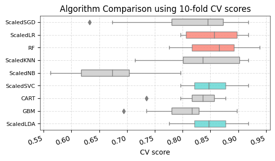

```python
# Compare Algorithms
plt.rcdefaults()
fig = plt.figure(figsize = (6,3))
ax = fig.add_subplot(111)
sns.boxplot(data = tmp, color = 'lightgrey', linewidth = 1, width = 0.5, orient = 'h')

# Coloring box-plots of top 2 mean values
n = 2
algorithm_index = tmp1['mean'].index.to_list()
top_2_idx = tmp1['mean'].argsort()[::-1][:n].values

for i in top_2_idx :
    # Select which box you want to change
    mybox = ax.patches[i]

    # Change the appearance of that box
    mybox.set_facecolor('salmon')
    mybox.set_alpha(0.8)
    # mybox.set_edgecolor('black')
    # mybox.set_linewidth(3)

# Coloring box-plots of 3rd and 4th mean values
top_3_4_idx = tmp1['mean'].argsort()[::-1][2:4].values
for i in top_3_4_idx :
    # Select which box you want to change
    mybox = ax.patches[i]

    # Change the appearance of that box
    mybox.set_facecolor('mediumturquoise')
    mybox.set_alpha(0.7)
    # mybox.set_edgecolor('black')
    # mybox.set_linewidth(3)

ax.grid(True, alpha = 0.4, ls = '--')
ax.set_axisbelow(True)
[labels.set(rotation = 20, ha = 'right') for labels in ax.get_xticklabels()]
[labels.set(size = 8) for labels in ax.get_yticklabels()]

for key, _  in ax.spines._dict.items():
    ax.spines._dict[key].set_linewidth(.5)

ax.set_title('Algorithm Comparison using 10-fold CV scores', ha = 'center' )
ax.set_xlabel('CV score')
#ax.set_ylim(0.6,1)
plt.show()
fig.savefig(path+'spotchecking algorithms using 10 fold CV.png', dpi = 175)
```

## Results from simple Train Test split

```python
display_results(dict_perf).style.background_gradient(cmap='Blues')
```

|  | Accuracy Train | Accuracy Test | F1 Train | F1 Test | Recall Train | Recall Test | Precision Train | Precision Test |
| --- | --- | --- | --- | --- | --- | --- | --- | --- |
| SGD Classifier | 0.8528 | 0.8049 | 0.8531 | 0.8053 | 0.8528 | 0.8049 | 0.8568 | 0.8117 |
| Logistic Regression Classifier | 0.8855 | 0.8902 | 0.8857 | 0.8905 | 0.8855 | 0.8902 | 0.8878 | 0.8974 |
| Random Forest Classifier | 0.9141 | 0.8902 | 0.9142 | 0.8904 | 0.9141 | 0.8902 | 0.9144 | 0.8917 |
| k-Nearest Neighbor Classifier | 0.8712 | 0.8720 | 0.8707 | 0.8717 | 0.8712 | 0.8720 | 0.8719 | 0.8720 |
| Gaussian Naive Bayes Classifier | 0.8487 | 0.8354 | 0.8475 | 0.8335 | 0.8487 | 0.8354 | 0.8512 | 0.8395 |
| Support Vector Classifier | 0.8650 | 0.8841 | 0.8652 | 0.8842 | 0.8650 | 0.8841 | 0.8738 | 0.8992 |
| Decision Tree Classifier | 0.9182 | 0.8354 | 0.9181 | 0.8347 | 0.9182 | 0.8354 | 0.9184 | 0.8356 |
| Gradient Boosting Classifier | 0.9939 | 0.8780 | 0.9939 | 0.8783 | 0.9939 | 0.8780 | 0.9939 | 0.8795 |
| Linear Discriminant Analysis Classifier | 0.8691 | 0.8780 | 0.8693 | 0.8780 | 0.8691 | 0.8780 | 0.8789 | 0.8949 |

## Selecting the Algorithms from K-Fold cross validation

From both simple train/test/split and cross validation methods, we have shortlisted the below two classifiers with the highest accuracy measures :  
-- Logistic Regression Classifier and  
-- Random Forest Classifier

# Tuning the Selected Algorithm

## Tuning Logistic Regression Classifier

```python
# https://stackoverflow.com/questions/62331674/sklearn-combine-gridsearchcv-with-column-transform-and-pipeline?noredirect=1&lq=1

from sklearn.preprocessing import StandardScaler, OneHotEncoder
from sklearn.compose import make_column_transformer
from sklearn.compose import make_column_selector
import pandas as pd  # doctest: +SKIP

# define dataset
X, y = X_train, y_train

from sklearn.compose import make_column_selector
from sklearn.pipeline import make_pipeline, Pipeline
from sklearn.model_selection import GridSearchCV
from sklearn.impute import KNNImputer
from sklearn.linear_model import LinearRegression
from sklearn.model_selection import cross_val_score, KFold, RepeatedStratifiedKFold
from sklearn.impute import SimpleImputer
from sklearn.preprocessing import OneHotEncoder


#numerical_features=make_column_selector(dtype_include=np.number)
#cat_features=make_column_selector(dtype_exclude=np.number)

num_attribs = ['A2', 'A3','A8', 'A11', 'A14', 'A15']
cat_attribs = ["A1","A4", "A5", "A6", "A7", "A9", "A10", "A12", "A13"]

# Setting the pipeline for preprocessing numeric and categorical variables
preprocessor = ColumnTransformer([
    ("num", num_pipeline, num_attribs),
    ("cat", OneHotEncoder(handle_unknown='ignore'), cat_attribs)])

# Creating a composite estimator by appending classifier estimator to preprocessor pipeline
model_lr = make_pipeline(preprocessor,
                         LogisticRegression(random_state = 48, max_iter = 1000) )

# define models and parameters
#model = LogisticRegression()
solvers = ['newton-cg', 'lbfgs', 'liblinear']
penalty = ['l2']
c_values = [100, 10, 1.0, 0.1, 0.01]

# define grid search
grid_lr = dict(logisticregression__solver=solvers,
            logisticregression__penalty=penalty,
            logisticregression__C=c_values)

cv = RepeatedStratifiedKFold(n_splits=10, n_repeats=3, random_state=1)

# Instantiating GridSearchCV object with composite estimator, parameter grid, CV(crossvalidation generator)
grid_search_lr = GridSearchCV(estimator=model_lr, param_grid=grid_lr,
                              n_jobs=-1, cv=cv, scoring='accuracy',error_score=0)

grid_result_lr = grid_search_lr.fit(X, y)

# summarize results
print("Best: %f using %s" % (grid_result_lr.best_score_, grid_result_lr.best_params_))
means = grid_result_lr.cv_results_['mean_test_score']
stds = grid_result_lr.cv_results_['std_test_score']
params = grid_result_lr.cv_results_['params']
for mean, stdev, param in zip(means, stds, params):
    print("%f (%f) with: %r" % (mean, stdev, param))
```

```
Best: 0.860913 using {'logisticregression__C': 0.1, 'logisticregression__penalty': 'l2', 'logisticregression__solver': 'liblinear'}
0.847917 (0.054990) with: {'logisticregression__C': 100, 'logisticregression__penalty': 'l2', 'logisticregression__solver': 'newton-cg'}
0.847917 (0.054990) with: {'logisticregression__C': 100, 'logisticregression__penalty': 'l2', 'logisticregression__solver': 'lbfgs'}
0.847917 (0.054990) with: {'logisticregression__C': 100, 'logisticregression__penalty': 'l2', 'logisticregression__solver': 'liblinear'}
0.853387 (0.049407) with: {'logisticregression__C': 10, 'logisticregression__penalty': 'l2', 'logisticregression__solver': 'newton-cg'}
0.854082 (0.049850) with: {'logisticregression__C': 10, 'logisticregression__penalty': 'l2', 'logisticregression__solver': 'lbfgs'}
0.853387 (0.049407) with: {'logisticregression__C': 10, 'logisticregression__penalty': 'l2', 'logisticregression__solver': 'liblinear'}
0.852693 (0.046922) with: {'logisticregression__C': 1.0, 'logisticregression__penalty': 'l2', 'logisticregression__solver': 'newton-cg'}
0.852693 (0.046922) with: {'logisticregression__C': 1.0, 'logisticregression__penalty': 'l2', 'logisticregression__solver': 'lbfgs'}
0.852693 (0.046922) with: {'logisticregression__C': 1.0, 'logisticregression__penalty': 'l2', 'logisticregression__solver': 'liblinear'}
0.858844 (0.047125) with: {'logisticregression__C': 0.1, 'logisticregression__penalty': 'l2', 'logisticregression__solver': 'newton-cg'}
0.858844 (0.047125) with: {'logisticregression__C': 0.1, 'logisticregression__penalty': 'l2', 'logisticregression__solver': 'lbfgs'}
0.860913 (0.047333) with: {'logisticregression__C': 0.1, 'logisticregression__penalty': 'l2', 'logisticregression__solver': 'liblinear'}
0.837032 (0.054992) with: {'logisticregression__C': 0.01, 'logisticregression__penalty': 'l2', 'logisticregression__solver': 'newton-cg'}
0.837032 (0.054992) with: {'logisticregression__C': 0.01, 'logisticregression__penalty': 'l2', 'logisticregression__solver': 'lbfgs'}
0.840434 (0.051608) with: {'logisticregression__C': 0.01, 'logisticregression__penalty': 'l2', 'logisticregression__solver': 'liblinear'}
```

```python
set_config(display='text')
grid_result_lr.best_estimator_
```

```
Pipeline(steps=[('columntransformer',
                 ColumnTransformer(transformers=[('num',
                                                  Pipeline(steps=[('std_scaler',
                                                                   StandardScaler())]),
                                                  ['A2', 'A3', 'A8', 'A11',
                                                   'A14', 'A15']),
                                                 ('cat',
                                                  OneHotEncoder(handle_unknown='ignore'),
                                                  ['A1', 'A4', 'A5', 'A6', 'A7',
                                                   'A9', 'A10', 'A12',
                                                   'A13'])])),
                ('logisticregression',
                 LogisticRegression(C=0.1, max_iter=1000, random_state=48,
                                    solver='liblinear'))])
```

```python
set_config(display='diagram')
grid_search_lr.best_estimator_
```

```
Pipeline(steps=[('columntransformer',
                 ColumnTransformer(transformers=[('num',
                                                  Pipeline(steps=[('std_scaler',
                                                                   StandardScaler())]),
                                                  ['A2', 'A3', 'A8', 'A11',
                                                   'A14', 'A15']),
                                                 ('cat',
                                                  OneHotEncoder(handle_unknown='ignore'),
                                                  ['A1', 'A4', 'A5', 'A6', 'A7',
                                                   'A9', 'A10', 'A12',
                                                   'A13'])])),
                ('logisticregression',
                 LogisticRegression(C=0.1, max_iter=1000, random_state=48,
                                    solver='liblinear'))])
```

## Tuning RandomForest Classifier

```python
# https://stackoverflow.com/questions/62331674/sklearn-combine-gridsearchcv-with-column-transform-and-pipeline?noredirect=1&lq=1

from sklearn.preprocessing import StandardScaler, OneHotEncoder
from sklearn.compose import make_column_transformer
from sklearn.compose import make_column_selector
import pandas as pd  # doctest: +SKIP

# define dataset
X, y = X_train, y_train

from sklearn.compose import make_column_selector
from sklearn.pipeline import make_pipeline, Pipeline
from sklearn.model_selection import GridSearchCV
from sklearn.impute import KNNImputer
from sklearn.linear_model import LinearRegression
from sklearn.model_selection import cross_val_score, KFold
from sklearn.impute import SimpleImputer
from sklearn.preprocessing import OneHotEncoder


#numerical_features=make_column_selector(dtype_include=np.number)
#cat_features=make_column_selector(dtype_exclude=np.number)

num_attribs = ['A2', 'A3','A8', 'A11', 'A14', 'A15']
cat_attribs = ["A1","A4", "A5", "A6", "A7", "A9", "A10", "A12", "A13"]

preprocessor = ColumnTransformer([
    ("num", num_pipeline, num_attribs),
    ("cat", OneHotEncoder(handle_unknown='ignore'), cat_attribs)])

model_rf = make_pipeline(preprocessor, RandomForestClassifier())

# define model parameters
n_estimators = [10, 100, 1000]
max_features = ['sqrt', 'log2']

# define grid search
grid_rf = dict(randomforestclassifier__n_estimators=n_estimators,
            randomforestclassifier__max_features=max_features
           )

cv = RepeatedStratifiedKFold(n_splits=10, n_repeats=3, random_state=1)
grid_search_rf = GridSearchCV(estimator=model_rf, param_grid=grid_rf, n_jobs=-1, cv=cv, scoring='accuracy',error_score=0)
grid_result_rf = grid_search_rf.fit(X, y)

# summarize results
print("Best: %f using %s" % (grid_result_rf.best_score_, grid_result_rf.best_params_))
```

```
Best: 0.872562 using {'randomforestclassifier__max_features': 'sqrt', 'randomforestclassifier__n_estimators': 100}
```

```python
means = grid_result_rf.cv_results_['mean_test_score']
stds = grid_result_rf.cv_results_['std_test_score']
params = grid_result_rf.cv_results_['params']
for mean, stdev, param in zip(means, stds, params):
    print("%f (%f) with: %r" % (mean, stdev, param))
```

```
0.858149 (0.058613) with: {'randomforestclassifier__max_features': 'sqrt', 'randomforestclassifier__n_estimators': 10}
0.872562 (0.044866) with: {'randomforestclassifier__max_features': 'sqrt', 'randomforestclassifier__n_estimators': 100}
0.871840 (0.045962) with: {'randomforestclassifier__max_features': 'sqrt', 'randomforestclassifier__n_estimators': 1000}
0.850680 (0.045532) with: {'randomforestclassifier__max_features': 'log2', 'randomforestclassifier__n_estimators': 10}
0.869813 (0.046994) with: {'randomforestclassifier__max_features': 'log2', 'randomforestclassifier__n_estimators': 100}
0.871173 (0.043511) with: {'randomforestclassifier__max_features': 'log2', 'randomforestclassifier__n_estimators': 1000}
```

# Training the final Model on full training set

Since, **refit = True** in grid_search_lr (The GridSearchCV for logistic Regression),  
the best estimator - grid_result_lr.best*estimator* is the final model that is trained on the entire model.  
We will use the trained model to make predictions and assess performance on both training and test sets.

```python
# Inspecting the hyperparameters of the tuned estimator
```

```python
set_config(display='text')
grid_result_lr.best_estimator_
```

```
Pipeline(steps=[('columntransformer',
                 ColumnTransformer(transformers=[('num',
                                                  Pipeline(steps=[('std_scaler',
                                                                   StandardScaler())]),
                                                  ['A2', 'A3', 'A8', 'A11',
                                                   'A14', 'A15']),
                                                 ('cat',
                                                  OneHotEncoder(handle_unknown='ignore'),
                                                  ['A1', 'A4', 'A5', 'A6', 'A7',
                                                   'A9', 'A10', 'A12',
                                                   'A13'])])),
                ('logisticregression',
                 LogisticRegression(C=0.1, max_iter=1000, random_state=48,
                                    solver='liblinear'))])
```

```python
final_estimator = grid_result_lr.best_estimator_.named_steps['logisticregression']
print(final_estimator)
print('\n')
print('Coefficients of Logistic Regression Model : \n {}'.format(final_estimator.coef_))
```

```
LogisticRegression(C=0.1, max_iter=1000, random_state=48, solver='liblinear')


Coefficients of Logistic Regression Model :
 [[-6.58541123e-03 -3.51822076e-03  3.09711492e-01  4.70027755e-01
  -1.13323153e-01  4.35822579e-01  1.68285927e-02 -8.75341871e-02
   7.47808800e-02  7.28776727e-02 -2.18364147e-01  7.28776727e-02
   7.47808800e-02 -2.18364147e-01 -1.39144167e-01  4.01314072e-02
   4.11012844e-01  8.55332882e-03 -2.12058549e-02 -3.27693790e-01
  -1.76320240e-01 -2.68447620e-02 -2.30368098e-01 -2.52030447e-02
   4.08624678e-02  5.64167500e-03 -3.60899378e-02  4.05962577e-01
   6.25902716e-02  3.63074013e-02 -2.61934006e-01  1.02733304e-01
   5.97703732e-02  8.88998116e-02  8.68297921e-04 -7.75378510e-02
  -8.24031970e-02 -1.21443647e+00  1.14373088e+00 -3.02496249e-01
   2.31790655e-01  1.00373967e-02 -8.07429912e-02 -1.80524180e-02
  -1.20565649e-02 -4.05966115e-02]]
```

## Testing the model on entire train set

```python
final_model = grid_result_lr.best_estimator_

X_train_prepared = final_model['columntransformer'].transform(X_train)
train_predictions = final_model.named_steps['logisticregression'].predict(X_train_prepared)
```

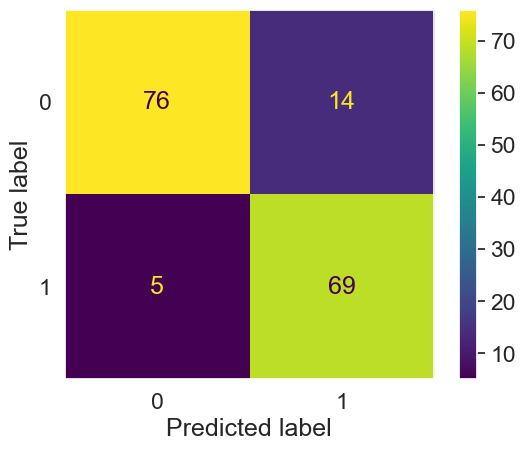

```python
# Testing the final model on test set
X_test, y_test = X_test, y_test
X_test_prepared = final_model['columntransformer'].transform(X_test)
final_predictions = final_model['logisticregression'].predict(X_test_prepared)

evaluation_parametrics(y_train,train_predictions,y_test,final_predictions)

cm = confusion_matrix(y_test,final_predictions, labels= final_model['logisticregression'].classes_)
disp = ConfusionMatrixDisplay(confusion_matrix=cm,
                              display_labels= final_model['logisticregression'].classes_)

sns.set(font_scale=1.5) # Adjust to fit
disp.plot()
plt.gca().grid(False)
plt.show()
```

```python
# Inspecting the pipeline objects
final_model.steps
```

```
[('columntransformer',
  ColumnTransformer(transformers=[('num',
                                   Pipeline(steps=[('std_scaler',
                                                    StandardScaler())]),
                                   ['A2', 'A3', 'A8', 'A11', 'A14', 'A15']),
                                  ('cat', OneHotEncoder(handle_unknown='ignore'),
                                   ['A1', 'A4', 'A5', 'A6', 'A7', 'A9', 'A10',
                                    'A12', 'A13'])])),
 ('logisticregression',
  LogisticRegression(C=0.1, max_iter=1000, random_state=48, solver='liblinear'))]
```

```python
final_model['columntransformer'].named_transformers_['num'].get_params()
#https://stackoverflow.com/questions/67374844/how-to-find-out-standardscaling-parameters-mean-and-scale-when-using-column
```

```
{'memory': None,
 'steps': [('std_scaler', StandardScaler())],
 'verbose': False,
 'std_scaler': StandardScaler(),
 'std_scaler__copy': True,
 'std_scaler__with_mean': True,
 'std_scaler__with_std': True}
```

```python
final_model['columntransformer'].named_transformers_['num'].named_steps['std_scaler'].__getstate__()
```

```
{'with_mean': True,
 'with_std': True,
 'copy': True,
 'feature_names_in_': array(['A2', 'A3', 'A8', 'A11', 'A14', 'A15'], dtype=object),
 'n_features_in_': 6,
 'n_samples_seen_': 489,
 'mean_': array([  31.64194274,    4.80782209,    2.16182004,    2.62167689,
         176.64212679, 1061.93251534]),
 'var_': array([1.44527358e+02, 2.44550009e+01, 1.08188797e+01, 2.72208798e+01,
        2.82397022e+04, 3.48843393e+07]),
 'scale_': array([1.20219532e+01, 4.94519979e+00, 3.28920655e+00, 5.21736330e+00,
        1.68046726e+02, 5.90629658e+03]),
 '_sklearn_version': '1.0.2'}
```

# Save model for later use

```python
import joblib
joblib.dump(final_model, 'credit-screening-lr.pkl')
```

```
['credit-screening-lr.pkl']
```

```python
clf = joblib.load('credit-screening-lr.pkl')
clf
```

```
Pipeline(steps=[('columntransformer',
                 ColumnTransformer(transformers=[('num',
                                                  Pipeline(steps=[('std_scaler',
                                                                   StandardScaler())]),
                                                  ['A2', 'A3', 'A8', 'A11',
                                                   'A14', 'A15']),
                                                 ('cat',
                                                  OneHotEncoder(handle_unknown='ignore'),
                                                  ['A1', 'A4', 'A5', 'A6', 'A7',
                                                   'A9', 'A10', 'A12',
                                                   'A13'])])),
                ('logisticregression',
                 LogisticRegression(C=0.1, max_iter=1000, random_state=48,
                                    solver='liblinear'))])
```

```python
print(list(dir(clf.named_steps['logisticregression'])))
```

[output not shown]

```python
clf.named_steps['logisticregression'].coef_
```

```
array([[-6.58541123e-03, -3.51822076e-03,  3.09711492e-01,
         4.70027755e-01, -1.13323153e-01,  4.35822579e-01,
         1.68285927e-02, -8.75341871e-02,  7.47808800e-02,
         7.28776727e-02, -2.18364147e-01,  7.28776727e-02,
         7.47808800e-02, -2.18364147e-01, -1.39144167e-01,
         4.01314072e-02,  4.11012844e-01,  8.55332882e-03,
        -2.12058549e-02, -3.27693790e-01, -1.76320240e-01,
        -2.68447620e-02, -2.30368098e-01, -2.52030447e-02,
         4.08624678e-02,  5.64167500e-03, -3.60899378e-02,
         4.05962577e-01,  6.25902716e-02,  3.63074013e-02,
        -2.61934006e-01,  1.02733304e-01,  5.97703732e-02,
         8.88998116e-02,  8.68297921e-04, -7.75378510e-02,
        -8.24031970e-02, -1.21443647e+00,  1.14373088e+00,
        -3.02496249e-01,  2.31790655e-01,  1.00373967e-02,
        -8.07429912e-02, -1.80524180e-02, -1.20565649e-02,
        -4.05966115e-02]])
```